# Project: tmdb-Movies Data Analysis

- Introduction
- Data Wrangling
- Exploratory Data Analysis
- Conclusions
- Limitations

## Introduction

Throughout this project, I will be exploring, analysing, and documenting my findings through a very interesting dataset of tmdb movies.

```python
#First, I'm importing important libraries I might be using through the project:

import numpy as np
import pandas as pd
import matplotlib.pyplot as plt
%matplotlib inline
import datetime as dt
import os
from timeit import default_timer as timer
from scipy import stats
from functools import reduce
import pandas.compat
import warnings
warnings.filterwarnings('ignore')
from os import path
import seaborn as sns
from wordcloud import WordCloud
from IPython.core.display import Image, display
import random
from wordcloud import WordCloud, STOPWORDS

#Adjust column width to enable visual investigations:
pd.set_option('max_colwidth', 500)
pd.set_option('display.max_columns', None)
pd.set_option("display.min_rows", 100)
```

## Data Wrangling

### General Properties

```python
df = pd.read_csv('tmdb-movies.csv')
df.sample(20)
# Load your data and print out a few lines. Perform operations to inspect data
#   types and look for instances of missing or possibly errant data.
```

|  | id | imdb_id | popularity | budget | revenue | original_title | cast | homepage | director | tagline | keywords | overview | runtime | genres | production_companies | release_date | vote_count | vote_average | release_year | budget_adj | revenue_adj |
| --- | --- | --- | --- | --- | --- | --- | --- | --- | --- | --- | --- | --- | --- | --- | --- | --- | --- | --- | --- | --- | --- |
| 8205 | 40508 | tt0112255 | 0.281576 | 0 | 0 | 3 Ninjas Knuckle Up | Victor Wong\|Charles Napier\|Michael Treanor\|Max Elliott Slade\|Chad Power | NaN | Shin Sang-ok | Tum Tum, Colt and Rocky are back for all new non-stop Ninja action! | underdog\|hero\|rivalry\|crime\|youth | Rocky, Colt and TumTum must battle an evil wealthy toxic waste dumper in order to save a local Indian tribe and their friend Joe. The 3 Ninjas must help find Joe's father and find a secret disk that c… | 85 | Adventure\|Action\|Comedy\|Family | TriStar Pictures | 4/7/95 | 14 | 4.1 | 1995 | 0.000000e+00 | 0.000000e+00 |
| 9545 | 15592 | tt0094715 | 0.232779 | 0 | 57041866 | Beaches | Bette Midler\|Barbara Hershey\|John Heard\|Spalding Gray\|Lainie Kazan | NaN | Garry Marshall | Some Friendships Last Forever | death of a friend\|female friendship\|death of mother\|childhood friend\|female singer | A privileged rich debutante and a cynical struggling entertainer share a turbulent, but strong childhood friendship over the years. | 123 | Comedy\|Drama | Touchstone Pictures\|Silver Screen Partners IV\|All Girl Productions | 12/21/88 | 24 | 6.3 | 1988 | 0.000000e+00 | 1.051790e+08 |
| 6198 | 1635 | tt0399201 | 2.623346 | 126000000 | 162949164 | The Island | Ewan McGregor\|Scarlett Johansson\|Djimon Hounsou\|Sean Bean\|Steve Buscemi | http://www.theisland-themovie.com/ | Michael Bay | Your time will come... | clone\|transplantation\|love of one's life\|dystopia\|genetics | Lincoln Six-Echo is a resident of a seemingly Utopian but contained facility in the year 2019. Like all of the inhabitants of this carefully controlled environment, Lincoln hopes to be chosen to go to… | 136 | Action\|Thriller\|Science Fiction\|Adventure | DreamWorks SKG\|Warner Bros.\|Parkes/MacDonald Productions | 7/20/05 | 1027 | 6.4 | 2005 | 1.406870e+08 | 1.819431e+08 |
| 6267 | 9388 | tt0427944 | 0.852969 | 6500000 | 24793509 | Thank You for Smoking | Aaron Eckhart\|Maria Bello\|Cameron Bright\|Adam Brody\|Sam Elliott | NaN | Jason Reitman | Tobacco lobbyist Nick Naylor is trying to SAVE YOUR ASH! | father-son relationship\|capitalism\|based on novel\|smoking\|lie | The chief spokesperson and lobbyist Nick Naylor is the Vice-President of the Academy of Tobacco Studies. He is talented in speaking and spins argument to defend the cigarette industry in the most diff… | 92 | Comedy\|Drama | Fox Searchlight Pictures\|Room 9 Entertainment | 9/5/05 | 341 | 7.1 | 2005 | 7.257661e+06 | 2.768352e+07 |
| 6392 | 21481 | tt0467421 | 0.612001 | 0 | 0 | Twitches | Tia Mowry\|Tamera Mowry\|Kristen Wilson\|Patrick Fabian\|Jennifer Robertson | NaN | Stuart Gillard | NaN | mother\|sister sister relationship\|twin sister\|magic\|adoption | Twins separated at birth, Camryn and Alex meet by chance for the first time on their 21st birthday and discover they're witches with the power to save their homeland of Coventry from the evil that thr… | 86 | Comedy\|Drama\|Family\|Fantasy\|TV Movie | Disney Channel | 10/14/05 | 44 | 5.0 | 2005 | 0.000000e+00 | 0.000000e+00 |
| 10340 | 25389 | tt0107529 | 0.298960 | 0 | 9532895 | Matinee | John Goodman\|Cathy Moriarty\|Simon Fenton\|Omri Katz\|Lisa Jakub | NaN | Joe Dante | Lawrence Woolsey presents the end of civilization as we know it. Make that... Proudly Presents! | florida\|cold war\|movie theater\|premiere\|bomb shelter | A showman introduces a small coastal town to a unique movie experience and capitalises on the Cuban Missile crisis hysteria with a kitschy horror extravaganza combining film effects, stage props and a… | 99 | Comedy\|Drama | Universal Pictures\|Falcon Productions\|Renfield Productions | 1/29/93 | 15 | 6.0 | 1993 | 0.000000e+00 | 1.438962e+07 |
| 8896 | 9387 | tt0082198 | 1.176922 | 20000000 | 68851475 | Conan the Barbarian | Arnold Schwarzenegger\|James Earl Jones\|Max von Sydow\|Sandahl Bergman\|Cassandra Gava | NaN | John Milius | Thief. Warrior. Gladiator. King. | gladiator\|repayment\|despot\|barbarian\|sword and sorcerery | John Milius's jingoistic direction and pulpy screenplay fit perfectly into this film version of the Robert E. Howard fantasy story of the sword and sorcery hero, Conan the Barbarian. The story begins … | 129 | Adventure\|Fantasy\|Action | Universal Pictures\|Dino De Laurentiis Company | 4/2/82 | 356 | 6.5 | 1982 | 4.519285e+07 | 1.555797e+08 |
| 8168 | 13531 | tt0112950 | 0.414740 | 0 | 0 | Empire Records | Anthony LaPaglia\|Debi Mazar\|Maxwell Caulfield\|Liv Tyler\|Robin Tunney | NaN | Allan Moyle | They're selling music but not selling out. | cupcake\|twenty something\|gameboy\|money bag\|sidewalk | The employees of an independent music store learn about each other as they try anything to stop the store being absorbed by a large chain. | 90 | Comedy\|Drama | Monarchy Enterprises B.V.\|Warner Bros.\|New Regency Pictures | 9/22/95 | 95 | 6.9 | 1995 | 0.000000e+00 | 0.000000e+00 |
| 7867 | 42172 | tt0079271 | 0.167108 | 0 | 0 | Hardcore | George C. Scott\|Peter Boyle\|Season Hubley\|Dick Sargent\|Leonard Gaines | NaN | Paul Schrader | Oh my God, that's my daughter. | pornography\|runaway\|snuff\|daughter\|father | A conservative Midwest businessman ventures into the sordid underworld of pornography in California to look for his runaway teenage daughter who is making porno films in the porno pits of Los Angeles. | 109 | Crime\|Drama\|Thriller | Columbia Pictures Corporation\|A-Team | 2/9/79 | 16 | 6.1 | 1979 | 0.000000e+00 | 0.000000e+00 |
| 4708 | 86703 | tt2043757 | 0.265119 | 0 | 0 | 2-Headed Shark Attack | Carmen Electra\|Charlie O'Connell\|Brooke Hogan\|Gerald Webb\|David Gallegos | http://www.theasylum.cc/product.php?id=194 | Christopher Ray | 1 Body, 2 Heads and 6,000 Teeth | monster\|shark\|animal attack | A Semester at Sea ship is attacked and sunk by a mutated two-headed shark, and the survivors seek refuge on a deserted atoll. The coeds, however, are no longer safe when the atoll starts flooding. | 90 | Horror\|Action\|Thriller\|Science Fiction | The Asylum | 1/17/12 | 24 | 3.4 | 2012 | 0.000000e+00 | 0.000000e+00 |
| 2048 | 45657 | tt1369706 | 0.745434 | 10000000 | 498974 | The Ward | Lyndsy Fonseca\|Amber Heard\|Danielle Panabaker\|Jared Harris\|Mamie Gummer | http://www.theofficialjohncarpenter.com/the-ward/ | John Carpenter | Only Sanity Can Keep You Alive | nurse\|mental disease\|orderly\|farm\|electric shock | A thriller centered on an institutionalized young woman who becomes terrorized by a ghost. | 88 | Horror\|Thriller | North by Northwest Entertainment\|Premiere Picture\|A Bigger Boat\|FilmNation Entertainment\|Echo Lake Entertainment | 9/13/10 | 166 | 5.9 | 2010 | 1.000000e+07 | 4.989740e+05 |
| 8724 | 889 | tt0158622 | 0.632783 | 83000000 | 59468275 | The Flintstones in Viva Rock Vegas | Mark Addy\|Stephen Baldwin\|Kristen Johnston\|Jane Krakowski\|Joan Collins | http://www.vivarockvegas.com/ | Brian Levant | Get ready to rock! | waitress\|marriage proposal\|flirt\|stone age\|best friend | The Flintstones are at it again. The Flintstones and the Rubbles head for Rock Vegas with Fred hoping to court the lovely Wilma. Nothing will stand in the way of love, except for the conniving Chip Ro… | 90 | Science Fiction\|Comedy\|Family\|Romance | Universal Pictures\|Amblin Entertainment | 4/28/00 | 55 | 4.4 | 2000 | 1.051022e+08 | 7.530421e+07 |
| 6994 | 5137 | tt0346156 | 1.590381 | 70000000 | 57958696 | Sky Captain and the World of Tomorrow | Jude Law\|Gwyneth Paltrow\|Giovanni Ribisi\|Angelina Jolie\|Bai Ling | http://www.skycaptain.com/ | Kerry Conran | Who will save us? | london\|himalaya\|journalist\|killer robot\|computer war | When gigantic robots attack New York City, "Sky Captain" uses his private air force to fight them off. His ex-girlfriend, reporter Polly Perkins, has been investigating the recent disappearance of pro… | 107 | Mystery\|Action\|Thriller\|Science Fiction\|Adventure | Paramount Pictures\|Natural Nylon Entertainment\|Riff Raff Film Productions\|Filmauro\|Blue Flower Productions | 9/17/04 | 249 | 5.7 | 2004 | 8.081118e+07 | 6.691015e+07 |
| 3255 | 16450 | tt0977214 | 0.172834 | 0 | 0 | Hero Wanted | Cuba Gooding Jr.\|Ray Liotta\|Norman Reedus\|Kim Coates\|Tommy Flanagan | NaN | Brian Smrz | NaN | robbery\|revenge\|murder\|child in peril\|hospital | Liam Case is a garbage man whose life hasn't quite turned out the way he expected it would. In order to impress the girl of his dreams, Liam plans an elaborate heist that will culminate with him jumpi… | 95 | Action\|Adventure\|Crime\|Drama\|Thriller | NaN | 3/28/08 | 15 | 5.2 | 2008 | 0.000000e+00 | 0.000000e+00 |
| 5396 | 14398 | tt0118900 | 0.179786 | 0 | 5790448 | Gang Related | Jim Belushi\|Tupac Shakur\|Lela Rochon\|Dennis Quaid\|James Earl Jones | NaN | Jim Kouf | Some cops play by the rules. Their own. | detective\|surgeon\|stripper\|profanity\|murder | Two corrupt cops have a successful, seemingly perfect money making scheme- they sell drugs that they seize from dealers, kill the dealers, and blame the crimes on street gangs. Their scheme is going a… | 102 | Action\|Drama | Orion Pictures\|Kouf/Bigelow Productions | 10/8/97 | 16 | 6.4 | 1997 | 0.000000e+00 | 7.866094e+06 |
| 6812 | 13198 | tt0477139 | 0.275745 | 0 | 0 | Wristcutters: A Love Story | Patrick Fugit\|Shannyn Sossamon\|Shea Whigham\|Leslie Bibb\|Will Arnett | http://wristcutters.com/official_site | Goran Dukic | Life is a trip, but the afterlife is one hell of a ride. | independent film\|ex boyfriend ex girlfriend relationship\|breakup\|rolling a cigarette\|autocide | Zia, distraught over breaking up with his girlfriend, decides to end it all. Unfortunately, he discovers that there is no real ending, only a run-down afterlife that is strikingly similar to his old o… | 88 | Comedy\|Drama\|Fantasy\|Romance | No Matter Pictures | 1/24/06 | 73 | 6.4 | 2006 | 0.000000e+00 | 0.000000e+00 |
| 6111 | 10176 | tt0089869 | 0.636546 | 1000000 | 0 | The Quiet Earth | Bruno Lawrence\|Alison Routledge\|Anzac Wallace\|Pete Smith\|Tom Hyde | NaN | Geoff Murphy | The End of the World is Just the Beginning | bomb\|sex\|based on novel\|experiment\|nudity | After a top-secret experiment misfires, a scientist may be the only man left alive in the world. | 91 | Drama\|Science Fiction\|Thriller | Cinepro\|Mr. Yellowbeard Productions Limited & Company | 9/8/85 | 58 | 6.4 | 1985 | 2.027166e+06 | 0.000000e+00 |
| 7590 | 14223 | tt0486051 | 0.425002 | 6000000 | 0 | Wind Chill | Emily Blunt\|Ashton Holmes\|Martin Donovan\|Ned Bellamy | NaN | Gregory Jacobs | There Are Worse Things Than Dying | terror\|winter\|paranoia\|cold\|supernatural | Two college students share a ride home for the holidays. When they break down on a deserted stretch of road, they're preyed upon by the ghosts of people who have died there. | 91 | Drama\|Horror\|Thriller | Section Eight\|TriStar Pictures\|Blueprint Pictures | 4/27/07 | 37 | 5.6 | 2007 | 6.310011e+06 | 0.000000e+00 |
| 9734 | 11356 | tt0063374 | 0.437877 | 0 | 0 | The Odd Couple | Jack Lemmon\|Walter Matthau\|John Fiedler\|Herb Edelman\|David Sheiner | NaN | Gene Saks | Even More Funny On The Screen... Than It Was As A Broadway And City-To-City Stage Smash! | roommate\|friends\|apartment\|neurotic | Felix Ungar has just broken up with his wife. Despondent, he goes to kill himself but is saved by his friend Oscar Madison. With nowhere else to go, Felix is urged by Oscar to move in with him, at lea… | 106 | Comedy | Paramount Pictures | 2/7/68 | 51 | 7.3 | 1968 | 0.000000e+00 | 0.000000e+00 |
| 4546 | 89185 | tt2008633 | 0.521810 | 0 | 0 | Radio Rebel | Debby Ryan\|Sarena Parmar\|Adam DiMarco\|Atticus Mitchell\|Siobhan Williams | http://tv.disney.go.com/disneychannel/originalmovies/radiorebel/ | Peter Howitt | Can the girl who never speaks... Become the voice of a generation? | shyness\|jealousy\|secret identity\|radio\|step daughter | High school senior Tara is so painfully shy that she dreads speaking to anyone in the hallways or getting called on in class. But in the privacy of her bedroom with her iPod in hand, she rocks out -- … | 90 | Comedy\|Drama\|Family\|TV Movie | Two 4 The Money Media | 2/17/12 | 103 | 5.8 | 2012 | 0.000000e+00 | 0.000000e+00 |

```python
df.shape
```

```
(10866, 21)
```

```python
df.describe()
```

|  | id | popularity | budget | revenue | runtime | vote_count | vote_average | release_year | budget_adj | revenue_adj |
| --- | --- | --- | --- | --- | --- | --- | --- | --- | --- | --- |
| count | 10866.000000 | 10866.000000 | 1.086600e+04 | 1.086600e+04 | 10866.000000 | 10866.000000 | 10866.000000 | 10866.000000 | 1.086600e+04 | 1.086600e+04 |
| mean | 66064.177434 | 0.646441 | 1.462570e+07 | 3.982332e+07 | 102.070863 | 217.389748 | 5.974922 | 2001.322658 | 1.755104e+07 | 5.136436e+07 |
| std | 92130.136561 | 1.000185 | 3.091321e+07 | 1.170035e+08 | 31.381405 | 575.619058 | 0.935142 | 12.812941 | 3.430616e+07 | 1.446325e+08 |
| min | 5.000000 | 0.000065 | 0.000000e+00 | 0.000000e+00 | 0.000000 | 10.000000 | 1.500000 | 1960.000000 | 0.000000e+00 | 0.000000e+00 |
| 25% | 10596.250000 | 0.207583 | 0.000000e+00 | 0.000000e+00 | 90.000000 | 17.000000 | 5.400000 | 1995.000000 | 0.000000e+00 | 0.000000e+00 |
| 50% | 20669.000000 | 0.383856 | 0.000000e+00 | 0.000000e+00 | 99.000000 | 38.000000 | 6.000000 | 2006.000000 | 0.000000e+00 | 0.000000e+00 |
| 75% | 75610.000000 | 0.713817 | 1.500000e+07 | 2.400000e+07 | 111.000000 | 145.750000 | 6.600000 | 2011.000000 | 2.085325e+07 | 3.369710e+07 |
| max | 417859.000000 | 32.985763 | 4.250000e+08 | 2.781506e+09 | 900.000000 | 9767.000000 | 9.200000 | 2015.000000 | 4.250000e+08 | 2.827124e+09 |

- minimum and maximum runtime suggest invalid enteries or outliers, we'll assume that a typical movie runtime shall be at least 45 minutes and maximum 200 minutes!
- We may add another variable refering to the profit, which can be calculated from: Profit = Revenue - Budget , however, many budget and revenue are set to zero and will need further investigation.

```python
df.loc[df.revenue_adj==0]
```

|  | id | imdb_id | popularity | budget | revenue | original_title | cast | homepage | director | tagline | keywords | overview | runtime | genres | production_companies | release_date | vote_count | vote_average | release_year | budget_adj | revenue_adj |
| --- | --- | --- | --- | --- | --- | --- | --- | --- | --- | --- | --- | --- | --- | --- | --- | --- | --- | --- | --- | --- | --- |
| 48 | 265208 | tt2231253 | 2.932340 | 30000000 | 0 | Wild Card | Jason Statham\|Michael Angarano\|Milo Ventimiglia\|Dominik García-Lorido\|Anne Heche | NaN | Simon West | Never bet against a man with a killer hand. | gambling\|bodyguard\|remake | When a Las Vegas bodyguard with lethal skills and a gambling problem gets in trouble with the mob, he has one last play… and it's all or nothing. | 92 | Thriller\|Crime\|Drama | Current Entertainment\|Lionsgate\|Sierra / Affinity\|SJ Heat Productions\|Silver State Production Services | 1/14/15 | 481 | 5.3 | 2015 | 2.759999e+07 | 0.0 |
| 67 | 334074 | tt3247714 | 2.331636 | 20000000 | 0 | Survivor | Pierce Brosnan\|Milla Jovovich\|Dylan McDermott\|Angela Bassett\|Robert Forster | http://survivormovie.com/ | James McTeigue | His Next Target is Now Hunting Him | new year's eve\|fire\|showdown\|terrorist\|embassy | A Foreign Service Officer in London tries to prevent a terrorist attack set to hit New York, but is forced to go on the run when she is framed for crimes she did not commit. | 96 | Crime\|Thriller\|Action | Nu Image Films\|Winkler Films\|Millennium Films\|Survivor Productions | 5/21/15 | 280 | 5.4 | 2015 | 1.839999e+07 | 0.0 |
| 74 | 347096 | tt3478232 | 2.165433 | 0 | 0 | Mythica: The Darkspore | Melanie Stone\|Kevin Sorbo\|Adam Johnson\|Jake Stormoen\|Rocky Myers | http://www.mythicamovie.com/#!blank/wufvh | Anne K. Black | NaN | sword\|magic\|sorcery\|necromancer\|woman director | When Teela’s sister is murdered and a powerful relic stolen, Marek and her friends face a sinister new enemy – Kishkumen, a foreign mystic bent on reclaiming the Darkspore for his master Szorlok. … | 108 | Action\|Adventure\|Fantasy | Arrowstorm Entertainment | 6/24/15 | 27 | 5.1 | 2015 | 0.000000e+00 | 0.0 |
| 75 | 308369 | tt2582496 | 2.141506 | 0 | 0 | Me and Earl and the Dying Girl | Thomas Mann\|RJ Cyler\|Olivia Cooke\|Connie Britton\|Nick Offerman | http://www.foxsearchlight.com/meandearlandthedyinggirl/ | Alfonso Gomez-Rejon | A Little Friendship Never Killed Anyone. | tattoo\|high school\|leukemia\|friends\|parody | Greg is coasting through senior year of high school as anonymously as possible, avoiding social interactions like the plague while secretly making spirited, bizarre films with Earl, his only friend. B… | 105 | Comedy\|Drama | Indian Paintbrush | 6/12/15 | 569 | 7.7 | 2015 | 0.000000e+00 | 0.0 |
| 92 | 370687 | tt3608646 | 1.876037 | 0 | 0 | Mythica: The Necromancer | Melanie Stone\|Adam Johnson\|Kevin Sorbo\|Nicola Posener\|Jake Stormoen | http://www.mythicamovie.com/#!blank/y9ake | A. Todd Smith | NaN | sword\|magic\|sorcery\|necromancer | Mallister takes Thane prisoner and forces Marek and her team on a quest. Marek tracks down the Necromancer for a final showdown for the Darkspore. | 0 | Fantasy\|Action\|Adventure | Arrowstorm Entertainment\|Camera 40 Productions\|Bellpond Films | 12/19/15 | 11 | 5.4 | 2015 | 0.000000e+00 | 0.0 |
| 93 | 307663 | tt3480796 | 1.872696 | 10000000 | 0 | Vice | Ambyr Childers\|Thomas Jane\|Bryan Greenberg\|Bruce Willis\|Johnathon Schaech | NaN | Brian A Miller | Where the future is your past. | artificial intelligence\|android\|self-awareness\|mercenary\|virtual reality | Julian Michaels has designed the ultimate resort: VICE, where anything goes and the customers can play out their wildest fantasies with artificial inhabitants who look, think and feel like humans. Whe… | 96 | Thriller\|Science Fiction\|Action\|Adventure | Grindstone Entertainment Group\|K5 International\|Emmett/Furla Films\|Aperture Entertainment | 1/16/15 | 181 | 4.1 | 2015 | 9.199996e+06 | 0.0 |
| 100 | 326359 | tt4007502 | 1.724712 | 0 | 0 | Frozen Fever | Kristen Bell\|Idina Menzel\|Jonathan Groff\|Josh Gad\|Chris Williams | NaN | Chris Buck\|Jennifer Lee | NaN | sister sister relationship\|birthday\|song\|birthday party\|flu | On Anna's birthday, Elsa and Kristoff are determined to give her the best celebration ever, but Elsa's icy powers may put more than just the party at risk. | 8 | Adventure\|Animation\|Family | Walt Disney Pictures\|Walt Disney Animation Studios | 3/9/15 | 475 | 7.0 | 2015 | 0.000000e+00 | 0.0 |
| 101 | 254302 | tt0462335 | 1.661789 | 0 | 0 | High-Rise | Tom Hiddleston\|Sienna Miller\|Jeremy Irons\|Luke Evans\|Elisabeth Moss | NaN | Ben Wheatley | Leave the real world behind | skyscraper\|high rise | Dr. Robert Laing is the newest resident of a luxurious apartment in a high-tech concrete skyscraper whose lofty location places him amongst the upper class. Laing quickly settles into high-society lif… | 119 | Action\|Drama\|Science Fiction | Ingenious Media\|HanWay Films\|Scope Pictures\|Recorded Picture Company (RPC)\|Northern Ireland Screen | 9/26/15 | 161 | 5.4 | 2015 | 0.000000e+00 | 0.0 |
| 103 | 292040 | tt3321300 | 1.646664 | 0 | 0 | Spooks: The Greater Good | Peter Firth\|Kit Harington\|Jennifer Ehle\|Lara Pulver\|Elyes Gabel | http://www.shinepictures.co.uk/films/9/spooks-the-greater-good/ | Bharat Nalluri | NaN | corruption\|terrorist\|explosive\|police\|kidnapping | During a handover to the head of counter-terrorism of MI5 Harry Pearce, terrorist Adam Qasim escapes from MI5 custody. When Harry disappears soon after, his protégé Will Crombie is tasked with findi… | 104 | Thriller\|Action | BBC Films\|Isle of Man Film\|Shine Pictures\|Kudos Film and Television\|Pinewood Pictures | 4/11/15 | 114 | 5.6 | 2015 | 0.000000e+00 | 0.0 |
| 116 | 297291 | tt3086386 | 1.380320 | 0 | 0 | The Scorpion King: The Lost Throne | Victor Webster\|Ellen Hollman\|Barry Bostwick\|Will Kemp\|M. Emmet Walsh | NaN | Mike Elliott | Action Adventure | magic\|fantasy\|steampunk\|dragon | When he is betrayed by a trusted friend, Mathayus must marshal all his strength and cunning to outwit a formidable opponent who will stop at nothing to unlock a supreme ancient power. | 105 | Action\|Fantasy\|Adventure | Universal Pictures | 1/9/15 | 22 | 4.5 | 2015 | 0.000000e+00 | 0.0 |
| 122 | 277355 | tt1945084 | 1.342839 | 0 | 0 | Everly | Salma Hayek\|Hiroyuki Watanabe\|Jennifer Blanc\|Togo Igawa\|Caroline Chikezie | NaN | Joe Lynch | Enter if you dare. | assassin\|mob boss | After she betrays a powerful mob boss, a woman matches wits and weaponry with a legion of killers who are out to collect the bounty on the heads of her and her family. | 90 | Thriller\|Action | Crime Scene Pictures\|Radius-TWC\|Anonymous Content\|Vega, Baby! | 1/23/15 | 169 | 5.1 | 2015 | 0.000000e+00 | 0.0 |
| 133 | 157827 | tt2217859 | 1.251681 | 11000000 | 0 | Louder Than Bombs | Gabriel Byrne\|Isabelle Huppert\|Jesse Eisenberg\|Devin Druid\|Amy Ryan | http://www.motlys.com/louder-than-bombs | Joachim Trier | NaN | usa\|brother brother relationship\|father-son relationship\|car accident\|death of mother | Three years after his wife, acclaimed photographer Isabelle Reed, dies in a car crash, Gene keeps everyday life going with his shy teenage son, Conrad. A planned exhibition of Isabelle’s photographs… | 109 | Drama | Motlys\|Arte France Cinéma\|Animal Kingdom | 5/18/15 | 43 | 6.3 | 2015 | 1.012000e+07 | 0.0 |
| 140 | 300803 | tt3829170 | 1.144808 | 0 | 0 | Dragonheart 3: The Sorcerer's Curse | Julian Morris\|Tamzin Merchant\|Jassa Ahluwalia\|Ben Kingsley\|Jonjo O'Neill | NaN | Colin Teague | NaN | magic\|wall\|druid\|knight\|dragon | When aspiring knight Gareth goes in search of a fallen comet rumored to contain gold, he is shocked to instead find the dragon Drago. After Drago saves Gareth's life the two become intricately bonded,… | 97 | Action\|Adventure\|Fantasy | Raffaella Productions | 2/24/15 | 59 | 4.5 | 2015 | 0.000000e+00 | 0.0 |
| 143 | 378373 | tt3532278 | 1.128081 | 0 | 0 | Brothers of the Wind | Manuel Camacho\|Jean Reno\|Tobias Moretti\|Eva Kuen | http://www.terramater.at/cinema/brothers-of-the-wind/ | Gerado Olivares\|Otmar Penker | Sometimes a friendship sets you free | eagle\|learning to fly\|eagle's feather\|father son conflict\|bird's nest | The way of the eagle is to raise two chicks. The stronger is destined always to throw the weaker from the nest. Man also has his ways, often to hurt those closest to him. Lukas suffers at the hands of… | 98 | Adventure\|Drama\|Family | Terra Mater Factual Studios | 12/24/15 | 11 | 7.5 | 2015 | 0.000000e+00 | 0.0 |
| 145 | 294963 | tt2494362 | 1.073349 | 1800000 | 0 | Bone Tomahawk | Kurt Russell\|Richard Jenkins\|Matthew Fox\|Lili Simmons\|Sean Young | NaN | S. Craig Zahler | May the Lord have mercy and grant you a swift death | poison\|prisoner\|murder\|rifle\|gore | During a shootout in a saloon, Sheriff Hunt injures a suspicious stranger. One of the villagers takes care of him in prison. One day they both disappear – only the spear of a cannibal tribe is found… | 132 | Horror\|Western\|Adventure\|Drama | Caliber Media Company\|The Fyzz Facility\|Realbuilder Productions | 10/23/15 | 220 | 6.3 | 2015 | 1.655999e+06 | 0.0 |
| 147 | 245698 | tt1596345 | 1.063055 | 0 | 0 | Pawn Sacrifice | Tobey Maguire\|Lily Rabe\|Peter Sarsgaard\|Liev Schreiber\|Sophie Nélisse | NaN | Edward Zwick | On the board he fought the Cold War. In his mind he fought his madness. | chess\|cold war\|russia\|biography\|victory | American chess champion Bobby Fischer prepares for a legendary match-up against Russian Boris Spassky. | 114 | Drama | Material Pictures\|MICA Entertainment\|PalmStar Media\|Gail Katz Productions | 9/16/15 | 148 | 6.6 | 2015 | 0.000000e+00 | 0.0 |
| 149 | 346808 | tt3181776 | 1.041922 | 20000000 | 0 | Momentum | Olga Kurylenko\|Morgan Freeman\|James Purefoy\|Jenna Saras\|Lee-Anne Summers | NaN | Stephen S. Campanelli | NaN | NaN | When Alex, an infiltration expert with a secret past, accidentally reveals her identity during what should have been a routine heist, she quickly finds herself mixed up in a government conspiracy and … | 96 | Thriller\|Action | Thaba Media\|Azari Media | 8/1/15 | 100 | 5.8 | 2015 | 1.839999e+07 | 0.0 |
| 151 | 290637 | tt3733778 | 1.036825 | 0 | 0 | Pay the Ghost | Nicolas Cage\|Sarah Wayne Callies\|Veronica Ferres\|Lyriq Bent\|Lauren Beatty | NaN | Uli Edel | Evil walks among us. | halloween\|police\|revenge\|burned alive\|children | One year after his young son disappeared during a Halloween carnival, Mike Cole is haunted by eerie images and terrifying messages he can’t explain. Together with his estranged wife, he will stop at… | 94 | Horror\|Thriller | Voltage Films\|Midnight Kitchen Productions | 9/16/15 | 114 | 5.3 | 2015 | 0.000000e+00 | 0.0 |
| 152 | 244458 | tt1567437 | 1.027620 | 0 | 0 | The Voices | Ryan Reynolds\|Gemma Arterton\|Anna Kendrick\|Jacki Weaver\|Ella Smith | NaN | Marjane Satrapi | Hearing voices can be murder. | violence\|psychiatrist\|dark\|evil\|woman director | A mentally unhinged factory worker must decide whether to listen to his talking cat and become a killer, or follow his dog's advice to keep striving for normalcy. | 101 | Horror\|Thriller\|Comedy\|Crime | Studio Babelsberg\|Mandalay Vision\|1984 Private Defense Contractors | 2/6/15 | 371 | 6.0 | 2015 | 0.000000e+00 | 0.0 |
| 154 | 314405 | tt3278330 | 1.008474 | 12000000 | 0 | Il racconto dei racconti | Salma Hayek\|Vincent Cassel\|John C. Reilly\|Toby Jones\|Shirley Henderson | NaN | Matteo Garrone | Desire. Envy. Obsession. | NaN | A fantasy film with horror elements, "The Tale of Tales" is loosely inspired by the 17th century collection of fairy tales of the same name by Italian writer Giambattista Basile. | 125 | Romance\|Fantasy\|Horror | HanWay Films\|Rai Cinema\|Le Pacte\|Fonds Eurimages du Conseil de l'Europe\|Recorded Picture Company (RPC) | 5/14/15 | 211 | 5.7 | 2015 | 1.104000e+07 | 0.0 |
| 156 | 157843 | tt1837636 | 0.973316 | 15000000 | 0 | Queen of the Desert | Nicole Kidman\|James Franco\|Robert Pattinson\|Damian Lewis\|Jenny Agutter | NaN | Werner Herzog | NaN | middle east\|persia\|adventurer | A chronicle of Gertrude Bell's life, a traveler, writer, archaeologist, explorer, cartographer, and political attaché for the British Empire at the dawn of the twentieth century. | 128 | Drama\|History | Benaroya Pictures\|H Films\|Raslan Company of America | 9/3/15 | 30 | 6.0 | 2015 | 1.379999e+07 | 0.0 |
| 158 | 290762 | tt2245003 | 0.953647 | 0 | 0 | Miss You Already | Drew Barrymore\|Toni Collette\|Dominic Cooper\|Jacqueline Bisset\|Paddy Considine | NaN | Catherine Hardwicke | When life falls apart, friends keep it together | female friendship\|music\|friendship\|love\|cancer | The friendship between two life-long girlfriends is put to the test when one starts a family and the other falls ill. | 112 | Comedy\|Drama\|Romance | S Films\|New Sparta Films | 9/12/15 | 139 | 7.2 | 2015 | 0.000000e+00 | 0.0 |
| 159 | 251516 | tt3472226 | 0.953046 | 630019 | 0 | Kung Fury | David Sandberg\|Jorma Taccone\|Leopold Nilsson\|Andreas Cahling\|Helene Ahlson | http://www.kungfury.com/ | David Sandberg | It takes a cop from the future to fight an enemy from the past. | video game\|martial arts\|kung fu\|hacker\|nazis | During an unfortunate series of events, a friend of Kung Fury is assassinated by the most dangerous kung fu master criminal of all time, Adolf Hitler, a.k.a Kung Führer. Kung Fury decides to travel b… | 31 | Action\|Comedy\|Science Fiction\|Fantasy | Laser Unicorns | 5/28/15 | 487 | 7.7 | 2015 | 5.796172e+05 | 0.0 |
| 164 | 228968 | tt2917388 | 0.917040 | 0 | 0 | Kidnapping Mr. Heineken | Anthony Hopkins\|Jim Sturgess\|Sam Worthington\|Ryan Kwanten\|Mark van Eeuwen | http://kidnappingmrheinekenmovie.com/ | Daniel Alfredson | It was the perfect crime until they got away with it. | NaN | The true story of the kidnapping of Freddy Heineken, the grandson of the founder of the Heineken brewery, and his driver. They were released after a ransom of 35 million Dutch guilders was paid. | 95 | Drama\|Action\|Crime\|Thriller | Umedia\|Informant Europe SPRL\|European Film Company | 3/12/15 | 131 | 5.8 | 2015 | 0.000000e+00 | 0.0 |
| 165 | 347969 | tt2479478 | 0.913085 | 60000000 | 0 | The Ridiculous 6 | Adam Sandler\|Taylor Lautner\|Steve Buscemi\|Terry Crews\|Danny Trejo | http://www.netflix.com/title/80039517 | Frank Coraci | NaN | wild west | When his long-lost outlaw father returns, Tommy "White Knife" Stockburn goes on an adventure-filled journey across the Old West with his five brothers. | 119 | Comedy\|Western | Happy Madison Productions | 12/11/15 | 252 | 4.8 | 2015 | 5.519998e+07 | 0.0 |
| 166 | 237756 | tt2393845 | 0.906860 | 0 | 0 | Kill Me Three Times | Teresa Palmer\|Simon Pegg\|Luke Hemsworth\|Sullivan Stapleton\|Alice Braga | NaN | Kriv Stenders | Once is never enough. | assassin\|dark comedy | While on a seemingly routine job, a jaded hit man discovers that he's not the only one with his target in the crosshairs. | 90 | Comedy\|Thriller | Parabolic Pictures\|Stable Way Entertainment\|Cargo Films\|Media House Capital | 4/10/15 | 96 | 5.1 | 2015 | 0.000000e+00 | 0.0 |
| 169 | 311291 | tt3544082 | 0.894477 | 0 | 0 | 45 Years | Charlotte Rampling\|Tom Courtenay\|Dolly Wells\|Geraldine James\|David Sibley | NaN | Andrew Haigh | NaN | secret\|marriage | There is just one week until Kate Mercer's 45th wedding anniversary and the planning for the party is going well. But then a letter arrives for her husband. The body of his first love has been discove… | 95 | Drama | The Bureau | 8/28/15 | 167 | 6.0 | 2015 | 0.000000e+00 | 0.0 |
| 174 | 342474 | tt3289712 | 0.861179 | 0 | 0 | Jenny's Wedding | Katherine Heigl\|Tom Wilkinson\|Alexis Bledel\|Grace Gummer\|Linda Emond | https://www.facebook.com/jennysweddingmovie | Mary Agnes Donoghue | Family is worth fighting for. | woman director | Jenny Farrell is getting married. But how will her straight-laced family react when they find out that the woman they thought was their daughter’s roommate is actually her fiancée? As the old-fashi… | 94 | Comedy\|Drama | MM Productions\|Merced Media Partners\|PalmStar Media | 7/31/15 | 92 | 5.2 | 2015 | 0.000000e+00 | 0.0 |
| 175 | 277217 | tt3440298 | 0.848748 | 0 | 0 | Descendants | Booboo Stewart\|Dove Cameron\|Keegan Connor Tracy\|Stephanie Bennett\|Dan Payne | NaN | Kenny Ortega | They're not bad. They're just born that way. | fairy tale\|villain\|musical\|teen movie\|teenager | A present-day idyllic kingdom where the benevolent teenage son of King Adam and Queen Belle offers a chance of redemption for the troublemaking offspring of Disney's classic villains: Cruella De Vil (… | 112 | Music\|Action\|Adventure\|Comedy\|Family | Walt Disney Television | 7/31/15 | 262 | 6.7 | 2015 | 0.000000e+00 | 0.0 |
| 176 | 207936 | tt2338424 | 0.843174 | 0 | 0 | Tumbledown | Joe Manganiello\|Jason Sudeikis\|Blythe Danner\|Rebecca Hall\|Dianna Agron | NaN | Sean Mewshaw | Turn the page. Start a new chapter. | widow\|biography\|writer\|folk singer | A young woman struggles to move on with her life after the death of her husband, an acclaimed folk singer, when a brash New York writer forces her to confront her loss and the ambiguous circumstances … | 105 | Music\|Romance\|Comedy | Echo Films\|Bron Studios\|Hahnscape | 4/18/15 | 22 | 6.6 | 2015 | 0.000000e+00 | 0.0 |
| ... | ... | ... | ... | ... | ... | ... | ... | ... | ... | ... | ... | ... | ... | ... | ... | ... | ... | ... | ... | ... | ... |
| 10834 | 12639 | tt0060897 | 0.310688 | 0 | 0 | Return of the Seven | Yul Brynner\|Robert Fuller\|Julián Mateos\|Warren Oates\|Claude Akins | NaN | Burt Kennedy | Between the law and the lawless - SEVEN again... MAGNIFICENT again! | mexico\|horseback riding\|male friendship\|sequel | Chico one of the remaining members of The Magnificent Seven now lives in the town that they (The Seven) helped. One day someone comes and takes most of the men prisoner. His wife seeks out Chris, the … | 95 | Action\|Western | C.B. Films S.A.\|The Mirisch Production Company | 10/19/66 | 14 | 5.1 | 1966 | 0.000000e+00 | 0.0 |
| 10836 | 38720 | tt0061170 | 0.239435 | 0 | 0 | Walk Don't Run | Cary Grant\|Samantha Eggar\|Jim Hutton\|John Standing\|Miiko Taka | NaN | Charles Walters | Run, don't walk to see Walk, Don't Run. | hotel room\|embassy\|olympics\|housing shortage | British industrialist Sir William Rutland - "Bill" to his friends - is in Tokyo on a business trip during the time of the Summer Olympic Games there in 1964. Having actually arrived in Tokyo two days … | 114 | Comedy\|Romance | Columbia Pictures Corporation | 1/1/66 | 11 | 5.8 | 1966 | 0.000000e+00 | 0.0 |
| 10837 | 19728 | tt0060177 | 0.291704 | 0 | 0 | The Blue Max | George Peppard\|James Mason\|Ursula Andress\|Jeremy Kemp\|Karl Michael Vogler | NaN | John Guillermin | There was no quiet on the Western Front! | world war i\|fighter pilot\|biplane\|flying ace | A young pilot in the German air force of 1918, disliked as lower-class and unchivalrous, tries ambitiously to earn the medal offered for 20 kills. | 156 | War\|Action\|Adventure\|Drama | Twentieth Century Fox Film Corporation | 6/21/66 | 12 | 5.5 | 1966 | 0.000000e+00 | 0.0 |
| 10838 | 22383 | tt0060862 | 0.151845 | 0 | 0 | The Professionals | Burt Lancaster\|Lee Marvin\|Robert Ryan\|Woody Strode\|Jack Palance | NaN | Richard Brooks | Rough, tough and ready. | mexico\|kidnapper\|plan\|rescue\|desert | The Professionals is a 1966 American Western film directed by Richard Brooks. A kidnap-rescue adventure set in about 1917, it features a small group of experts heading into Mexico to free the Mexican-… | 117 | Action\|Adventure\|Western | Columbia Pictures | 11/1/66 | 21 | 6.0 | 1966 | 0.000000e+00 | 0.0 |
| 10839 | 13353 | tt0060550 | 0.276133 | 0 | 0 | It's the Great Pumpkin, Charlie Brown | Christopher Shea\|Sally Dryer\|Kathy Steinberg\|Ann Altieri\|Gail DeFaria | NaN | Bill Melendez | Every year he rises from the pumpkin patch... | holiday | This classic "Peanuts" tale focuses on the thumb-sucking, blanket-holding Linus, and his touching faith in the "Great Pumpkin." When Linus discovers that no one else believes in the creature, he sets … | 25 | Family\|Animation | Warner Bros. Home Video | 10/27/66 | 49 | 7.2 | 1966 | 0.000000e+00 | 0.0 |
| 10840 | 34388 | tt0060437 | 0.102530 | 0 | 0 | Funeral in Berlin | Michael Caine\|Paul Hubschmid\|Oskar Homolka\|Eva Renzi\|Guy Doleman | NaN | Guy Hamilton | NaN | berlin\|berlin wall\|england\|spy\|cold war | Colonel Stok, a Soviet intelligence officer responsible for security at the Berlin Wall, appears to want to defect but the evidence is contradictory. Stok wants the British to handle his defection and… | 102 | Thriller | Lowndes Productions Limited | 12/22/66 | 13 | 5.7 | 1966 | 0.000000e+00 | 0.0 |
| 10841 | 42701 | tt0062262 | 0.264925 | 75000 | 0 | The Shooting | Will Hutchins\|Millie Perkins\|Jack Nicholson\|Warren Oates\|Charles Eastman | NaN | Monte Hellman | Suspenseful desert pursuit in the "High Noon" tradition. | horseback riding\|revenge\|pursuit\|desert\|whistling | A hired gun seeks to enact revenge on a group of bounty hunters in the Old West. | 82 | Western | Proteus Films | 10/23/66 | 12 | 5.5 | 1966 | 5.038511e+05 | 0.0 |
| 10842 | 36540 | tt0061199 | 0.253437 | 0 | 0 | Winnie the Pooh and the Honey Tree | Sterling Holloway\|Junius Matthews\|Sebastian Cabot\|Howard Morris\|Hal Smith | NaN | Wolfgang Reitherman | NaN | NaN | Christopher Robin's bear attempts to raid a beehive in a tall tree. | 25 | Animation\|Family | NaN | 1/1/66 | 12 | 7.9 | 1966 | 0.000000e+00 | 0.0 |
| 10843 | 29710 | tt0060588 | 0.252399 | 0 | 0 | Khartoum | Charlton Heston\|Laurence Olivier\|Richard Johnson\|Ralph Richardson\|Alexander Knox | NaN | Basil Dearden\|Eliot Elisofon | Where the Nile divides, the great Cinerama adventure begins! | islam\|siege\|sudan\|epic\|victorian england | English General Charles George Gordon, a devout Christian, is appointed military governor of Anglo-Egyptian Sudan by Prime Minister Gladstone. Ordered to evacuate Egyptians from the Sudan, General Gor… | 134 | Adventure\|Drama\|War\|History\|Action | Julian Blaustein Productions Ltd. | 6/9/66 | 12 | 5.8 | 1966 | 0.000000e+00 | 0.0 |
| 10844 | 23728 | tt0059557 | 0.236098 | 0 | 0 | Our Man Flint | James Coburn\|Lee J. Cobb\|Gila Golan\|Edward Mulhare\|Benson Fong | NaN | Daniel Mann | The ORIGINAL man of mystery! | spy\|spoof\|derek flint\|super spy | When scientists use eco-terrorism to impose their will on the world by affecting extremes in the weather, Intelligence Chief Cramden calls in top agent Derek Flint. | 108 | Adventure\|Comedy\|Fantasy\|Science Fiction | 20th Century Fox | 1/16/66 | 13 | 5.6 | 1966 | 0.000000e+00 | 0.0 |
| 10845 | 5065 | tt0059014 | 0.230873 | 0 | 0 | Carry On Cowboy | Sid James\|Jim Dale\|Angela Douglas\|Kenneth Williams\|Charles Hawtrey | NaN | Gerald Thomas | How the west was lost! | washington d.c.\|carry on | Stodge City is in the grip of the Rumpo Kid and his gang. Mistaken identity again takes a hand as a "sanitary engineer" (plumber) by the name of Marshal P. Knutt is mistaken for a law marshal! Being t… | 93 | Comedy\|Western | Peter Rogers Productions | 3/1/66 | 15 | 5.9 | 1966 | 0.000000e+00 | 0.0 |
| 10846 | 17102 | tt0059127 | 0.212716 | 0 | 0 | Dracula: Prince of Darkness | Christopher Lee\|Barbara Shelley\|Andrew Keir\|Francis Matthews\|Suzan Farmer | NaN | Terence Fisher | DEAD for Ten Years DRACULA, Prince of Darkness, LIVES AGAIN! | castle\|vampire\|dracula\|sequel\|blood | Whilst vacationing in the Carpathian Mountain, two couples stumble across the remains of Count Dracula's castle. The Count's trusted servant kills one of the men, suspending the body over the Count's … | 90 | Horror | Seven Arts Productions\|Hammer Film Productions | 1/9/66 | 16 | 5.7 | 1966 | 0.000000e+00 | 0.0 |
| 10847 | 28763 | tt0060548 | 0.034555 | 0 | 0 | Island of Terror | Peter Cushing\|Edward Judd\|Carole Gray\|Eddie Byrne\|Sam Kydd | NaN | Terence Fisher | How could they stop the devouring death...that lived by sucking on living human bones! | monster\|island\|fog\|bone\|creature | A small island community is overrun with creeping, blobbish, tentacled monsters which liquefy and digest the bones from living creatures. The community struggles to fight back. | 89 | Science Fiction\|Horror | Planet Film Productions\|Protelco | 6/20/66 | 13 | 5.3 | 1966 | 0.000000e+00 | 0.0 |
| 10849 | 28270 | tt0060445 | 0.206537 | 0 | 0 | Gambit | Michael Caine\|Shirley MacLaine\|Herbert Lom\|John Abbott\|Roger C. Carmel | NaN | Ronald Neame | Shirley MacLaine raises Michael Caine! | master thief | Harry Dean (Michael Caine) has a perfect plan to steal a priceless bust. The core of which is Nicole (Shirley MacLaine) a look alike for his marks late wife. Will the gambit go as planned? | 109 | Action\|Comedy\|Crime | Universal Pictures | 12/16/66 | 14 | 6.1 | 1966 | 0.000000e+00 | 0.0 |
| 10850 | 26268 | tt0060490 | 0.202473 | 0 | 0 | Harper | Paul Newman\|Lauren Bacall\|Julie Harris\|Arthur Hill\|Janet Leigh | NaN | Jack Smight | Harper takes a case - and the payoff is murder. | private eye\|lew harper | Harper is a cynical private eye in the best tradition of Bogart. He even has Bogie's Baby hiring him to find her missing husband, getting involved along the way with an assortment of unsavory characte… | 121 | Action\|Drama\|Thriller\|Crime\|Mystery | Warner Bros. | 2/23/66 | 14 | 6.0 | 1966 | 0.000000e+00 | 0.0 |
| 10851 | 15347 | tt0060182 | 0.342791 | 0 | 0 | Born Free | Virginia McKenna\|Bill Travers\|Geoffrey Keen\|Peter Lukoye\|Omar Chambati | NaN | James Hill | From The Pages Of The Beloved Best Seller... A Motion Picture To Delight All The World! | parents kids relationship\|famous score\|lion\|aggression by animal\|dead animal | Born Free (1966) is an Open Road Films Ltd./Columbia Pictures feature film starring Virginia McKenna and Bill Travers as Joy and George Adamson, a real-life couple who raised an orphaned lion cub to a… | 95 | Adventure\|Drama\|Action\|Family\|Foreign | High Road | 6/22/66 | 15 | 6.6 | 1966 | 0.000000e+00 | 0.0 |
| 10852 | 37301 | tt0060165 | 0.227220 | 0 | 0 | A Big Hand for the Little Lady | Henry Fonda\|Joanne Woodward\|Jason Robards\|Paul Ford\|Charles Bickford | NaN | Fielder Cook | All the action you can take...all the adventure you can wish for! | poker game | A naive traveler in Laredo gets involved in a poker game between the richest men in the area, jeopardizing all the money he has saved for the purpose of settling with his wife and child in San Antonio… | 95 | Western | Eden Productions Inc. | 5/31/66 | 11 | 6.0 | 1966 | 0.000000e+00 | 0.0 |
| 10853 | 15598 | tt0060086 | 0.163592 | 0 | 0 | Alfie | Michael Caine\|Shelley Winters\|Millicent Martin\|Julia Foster\|Jane Asher | NaN | Lewis Gilbert | Is any man an Alfie? Ask any girl! | womanizer\|playboy | The film tells the story of a young man who leads a promiscuous lifestyle until several life reversals make him rethink his purposes and goals in life. | 114 | Comedy\|Drama\|Romance | NaN | 3/29/66 | 26 | 6.2 | 1966 | 0.000000e+00 | 0.0 |
| 10854 | 31602 | tt0060232 | 0.146402 | 0 | 0 | The Chase | Marlon Brando\|Jane Fonda\|Robert Redford\|E.G. Marshall\|Angie Dickinson | NaN | Arthur Penn | The chase is on! | sheriff\|house party\|man hunt\|junkyard\|jump from train | Most everyone in town thinks that Sheriff Calder is merely a puppet of rich oil-man Val Rogers. When it is learned that local baddie Bubber Reeves has escaped prison, Rogers' son is concerned because … | 135 | Thriller\|Drama\|Crime | Horizon Pictures\|Columbia Pictures Corporation | 2/17/66 | 17 | 6.0 | 1966 | 0.000000e+00 | 0.0 |
| 10855 | 13343 | tt0059221 | 0.141026 | 700000 | 0 | The Ghost & Mr. Chicken | Don Knotts\|Joan Staley\|Liam Redmond\|Dick Sargent\|Skip Homeier | NaN | Alan Rafkin | G-G-GUARANTEED! YOU'LL BE SCARED UNTIL YOU LAUGH YOURSELF SILLY! | newspaper\|haunted house\|organ\|slapstick\|trial | Luther Heggs aspires to being a reporter for his small town newspaper. He gets his big break when the editor asks him to spend the night at the Simmons mansion that, 20 years before, was the site of a… | 90 | Comedy\|Family\|Mystery\|Romance | Universal Pictures | 1/20/66 | 14 | 6.1 | 1966 | 4.702610e+06 | 0.0 |
| 10856 | 20277 | tt0061135 | 0.140934 | 0 | 0 | The Ugly Dachshund | Dean Jones\|Suzanne Pleshette\|Charles Ruggles\|Kelly Thordsen\|Parley Baer | NaN | Norman Tokar | A HAPPY HONEYMOON GOES TO THE DOGS!...When a Great Dane disguised as a Dachsie crashes the party! | great dane\|dachshund | The Garrisons (Dean Jones and Suzanne Pleshette) are the "proud parents" of three adorable dachshund pups -- and one overgrown Great Dane named Brutus, who nevertheless thinks of himself as a dainty d… | 93 | Comedy\|Drama\|Family | Walt Disney Pictures | 2/16/66 | 14 | 5.7 | 1966 | 0.000000e+00 | 0.0 |
| 10857 | 5921 | tt0060748 | 0.131378 | 0 | 0 | Nevada Smith | Steve McQueen\|Karl Malden\|Brian Keith\|Arthur Kennedy\|Suzanne Pleshette | NaN | Henry Hathaway | Some called him savage- and some called him saint... some felt his hate- and one found his love... and three had to die... | repayment\|revenge\|native american\|wild west\|half breed | Nevada Smith is the young son of an Indian mother and white father. When his father is killed by three men over gold, Nevada sets out to find them and kill them. The boy is taken in by a gun merchant.… | 128 | Action\|Western | Paramount Pictures\|Solar Productions\|Embassy Pictures | 6/10/66 | 10 | 5.9 | 1966 | 0.000000e+00 | 0.0 |
| 10858 | 31918 | tt0060921 | 0.317824 | 0 | 0 | The Russians Are Coming, The Russians Are Coming | Carl Reiner\|Eva Marie Saint\|Alan Arkin\|Brian Keith\|Paul Ford | NaN | Norman Jewison | IT'S A PLOT! ...to make the world die laughing!! | cold war\|russian\|new england | Without hostile intent, a Soviet sub runs aground off New England. Men are sent for a boat, but many villagers go into a tizzy, risking bloodshed. | 126 | Comedy\|War | The Mirisch Corporation | 5/25/66 | 11 | 5.5 | 1966 | 0.000000e+00 | 0.0 |
| 10859 | 20620 | tt0060955 | 0.089072 | 0 | 0 | Seconds | Rock Hudson\|Salome Jens\|John Randolph\|Will Geer\|Jeff Corey | NaN | John Frankenheimer | NaN | plastic surgery\|suspense | A secret organisation offers wealthy people a second chance at life. The customer picks out someone they want to be and the organisation surgically alters the customer to look like the intended person… | 100 | Mystery\|Science Fiction\|Thriller\|Drama | Gibraltar Productions\|Joel Productions\|John Frankenheimer Productions Inc. | 10/5/66 | 22 | 6.6 | 1966 | 0.000000e+00 | 0.0 |
| 10860 | 5060 | tt0060214 | 0.087034 | 0 | 0 | Carry On Screaming! | Kenneth Williams\|Jim Dale\|Harry H. Corbett\|Joan Sims\|Charles Hawtrey | NaN | Gerald Thomas | Carry On Screaming with the Hilarious CARRY ON Gang!! | monster\|carry on\|horror spoof | The sinister Dr Watt has an evil scheme going. He's kidnapping beautiful young women and turning them into mannequins to sell to local stores. Fortunately for Dr Watt, Detective-Sergeant Bung is on th… | 87 | Comedy | Peter Rogers Productions\|Anglo-Amalgamated Film Distributors | 5/20/66 | 13 | 7.0 | 1966 | 0.000000e+00 | 0.0 |
| 10861 | 21 | tt0060371 | 0.080598 | 0 | 0 | The Endless Summer | Michael Hynson\|Robert August\|Lord 'Tally Ho' Blears\|Bruce Brown\|Chip Fitzwater | NaN | Bruce Brown | NaN | surfer\|surfboard\|surfing | The Endless Summer, by Bruce Brown, is one of the first and most influential surf movies of all times. The film documents American surfers Mike Hynson and Robert August as they travel the world during… | 95 | Documentary | Bruce Brown Films | 6/15/66 | 11 | 7.4 | 1966 | 0.000000e+00 | 0.0 |
| 10862 | 20379 | tt0060472 | 0.065543 | 0 | 0 | Grand Prix | James Garner\|Eva Marie Saint\|Yves Montand\|ToshirÅ Mifune\|Brian Bedford | NaN | John Frankenheimer | Cinerama sweeps YOU into a drama of speed and spectacle! | car race\|racing\|formula 1 | Grand Prix driver Pete Aron is fired by his team after a crash at Monaco that injures his teammate, Scott Stoddard. While Stoddard struggles to recover, Aron begins to drive for another team, and star… | 176 | Action\|Adventure\|Drama | Cherokee Productions\|Joel Productions\|Douglas & Lewis Productions | 12/21/66 | 20 | 5.7 | 1966 | 0.000000e+00 | 0.0 |
| 10863 | 39768 | tt0060161 | 0.065141 | 0 | 0 | Beregis Avtomobilya | Innokentiy Smoktunovskiy\|Oleg Efremov\|Georgi Zhzhyonov\|Olga Aroseva\|Lyubov Dobrzhanskaya | NaN | Eldar Ryazanov | NaN | car\|trolley\|stealing car | An insurance agent who moonlights as a carthief steals cars various crooks and never from the common people. He sells the stolen cars and gives the money to charity. His best friend, a cop, is assigne… | 94 | Mystery\|Comedy | Mosfilm | 1/1/66 | 11 | 6.5 | 1966 | 0.000000e+00 | 0.0 |
| 10864 | 21449 | tt0061177 | 0.064317 | 0 | 0 | What's Up, Tiger Lily? | Tatsuya Mihashi\|Akiko Wakabayashi\|Mie Hama\|John Sebastian\|Tadao Nakamaru | NaN | Woody Allen | WOODY ALLEN STRIKES BACK! | spoof | In comic Woody Allen's film debut, he took the Japanese action film "International Secret Police: Key of Keys" and re-dubbed it, changing the plot to make it revolve around a secret egg salad recipe. | 80 | Action\|Comedy | Benedict Pictures Corp. | 11/2/66 | 22 | 5.4 | 1966 | 0.000000e+00 | 0.0 |
| 10865 | 22293 | tt0060666 | 0.035919 | 19000 | 0 | Manos: The Hands of Fate | Harold P. Warren\|Tom Neyman\|John Reynolds\|Diane Mahree\|Stephanie Nielson | NaN | Harold P. Warren | It's Shocking! It's Beyond Your Imagination! | fire\|gun\|drive\|sacrifice\|flashlight | A family gets lost on the road and stumbles upon a hidden, underground, devil-worshiping cult led by the fearsome Master and his servant Torgo. | 74 | Horror | Norm-Iris | 11/15/66 | 15 | 1.5 | 1966 | 1.276423e+05 | 0.0 |

6016 rows × 21 columns

```python
df.loc[df.budget_adj==0]
```

|  | id | imdb_id | popularity | budget | revenue | original_title | cast | homepage | director | tagline | keywords | overview | runtime | genres | production_companies | release_date | vote_count | vote_average | release_year | budget_adj | revenue_adj |
| --- | --- | --- | --- | --- | --- | --- | --- | --- | --- | --- | --- | --- | --- | --- | --- | --- | --- | --- | --- | --- | --- |
| 30 | 280996 | tt3168230 | 3.927333 | 0 | 29355203 | Mr. Holmes | Ian McKellen\|Milo Parker\|Laura Linney\|Hattie Morahan\|Patrick Kennedy | http://www.mrholmesfilm.com/ | Bill Condon | The man behind the myth | london\|detective\|sherlock holmes | The story is set in 1947, following a long-retired Holmes living in a Sussex village with his housekeeper and rising detective son. But then he finds himself haunted by an unsolved 50-year old case. H… | 103 | Mystery\|Drama | BBC Films\|See-Saw Films\|FilmNation Entertainment\|Archer Gray\|AI-Film | 6/19/15 | 425 | 6.4 | 2015 | 0.0 | 2.700677e+07 |
| 36 | 339527 | tt1291570 | 3.358321 | 0 | 22354572 | Solace | Abbie Cornish\|Jeffrey Dean Morgan\|Colin Farrell\|Anthony Hopkins\|Marley Shelton | NaN | Afonso Poyart | A serial killer who can see your future, a psychic who can save it | thriller\|serial killer\|psychic\|fbi agent\|intrigue | A psychic doctor, John Clancy, works with an FBI special agent in search of a serial killer. After having lived in isolation for two years, since the death of his daughter, Clancy is asked by his frie… | 101 | Crime\|Drama\|Mystery | Eden Rock Media\|FilmNation Entertainment\|Flynn Picture Company | 9/3/15 | 474 | 6.2 | 2015 | 0.0 | 2.056620e+07 |
| 72 | 284289 | tt2911668 | 2.272044 | 0 | 45895 | Beyond the Reach | Michael Douglas\|Jeremy Irvine\|Hanna Mangan Lawrence\|Ronny Cox\|Martin Palmer | NaN | Jean-Baptiste Léonetti | NaN | desert\|hunting | A high-rolling corporate shark and his impoverished young guide play the most dangerous game during a hunting trip in the Mojave Desert. | 95 | Thriller | Furthur Films | 4/17/15 | 81 | 5.5 | 2015 | 0.0 | 4.222338e+04 |
| 74 | 347096 | tt3478232 | 2.165433 | 0 | 0 | Mythica: The Darkspore | Melanie Stone\|Kevin Sorbo\|Adam Johnson\|Jake Stormoen\|Rocky Myers | http://www.mythicamovie.com/#!blank/wufvh | Anne K. Black | NaN | sword\|magic\|sorcery\|necromancer\|woman director | When Teela’s sister is murdered and a powerful relic stolen, Marek and her friends face a sinister new enemy – Kishkumen, a foreign mystic bent on reclaiming the Darkspore for his master Szorlok. … | 108 | Action\|Adventure\|Fantasy | Arrowstorm Entertainment | 6/24/15 | 27 | 5.1 | 2015 | 0.0 | 0.000000e+00 |
| 75 | 308369 | tt2582496 | 2.141506 | 0 | 0 | Me and Earl and the Dying Girl | Thomas Mann\|RJ Cyler\|Olivia Cooke\|Connie Britton\|Nick Offerman | http://www.foxsearchlight.com/meandearlandthedyinggirl/ | Alfonso Gomez-Rejon | A Little Friendship Never Killed Anyone. | tattoo\|high school\|leukemia\|friends\|parody | Greg is coasting through senior year of high school as anonymously as possible, avoiding social interactions like the plague while secretly making spirited, bizarre films with Earl, his only friend. B… | 105 | Comedy\|Drama | Indian Paintbrush | 6/12/15 | 569 | 7.7 | 2015 | 0.0 | 0.000000e+00 |
| 88 | 301875 | tt3289728 | 1.959765 | 0 | 2000000 | Equals | Kristen Stewart\|Nicholas Hoult\|Guy Pearce\|Jacki Weaver\|Bel Powley | http://equals-the-movie.com/ | Drake Doremus | Find your equal. | illustrator\|sex scene\|near future\|infected\|emotions | A futuristic love story set in a world where emotions have been eradicated. | 101 | Drama\|Romance\|Science Fiction | Scott Free Productions\|Infinite Frameworks Studios\|Freedom Media\|Route One Entertainment | 9/4/15 | 135 | 5.6 | 2015 | 0.0 | 1.839999e+06 |
| 92 | 370687 | tt3608646 | 1.876037 | 0 | 0 | Mythica: The Necromancer | Melanie Stone\|Adam Johnson\|Kevin Sorbo\|Nicola Posener\|Jake Stormoen | http://www.mythicamovie.com/#!blank/y9ake | A. Todd Smith | NaN | sword\|magic\|sorcery\|necromancer | Mallister takes Thane prisoner and forces Marek and her team on a quest. Marek tracks down the Necromancer for a final showdown for the Darkspore. | 0 | Fantasy\|Action\|Adventure | Arrowstorm Entertainment\|Camera 40 Productions\|Bellpond Films | 12/19/15 | 11 | 5.4 | 2015 | 0.0 | 0.000000e+00 |
| 95 | 258509 | tt2974918 | 1.841779 | 0 | 233755553 | Alvin and the Chipmunks: The Road Chip | Jason Lee\|Justin Long\|Bella Thorne\|Matthew Gray Gubler\|Jesse McCartney | http://www.foxmovies.com/movies/alvin-and-the-chipmunks-the-road-chip | Walt Becker | Fast & furry-ous | chipmunk\|cgi\|talking animal\|aftercreditsstinger\|duringcreditsstinger | Through a series of misunderstandings, Alvin, Simon and Theodore come to believe that Dave is going to propose to his new girlfriend in New York City - and dump them. They have three days to get to hi… | 92 | Adventure\|Animation\|Comedy\|Family | Regency Enterprises\|Fox 2000 Pictures\|Sunswept Entertainment\|Bagdasarian Productions\|TSG Entertainment | 12/17/15 | 278 | 5.7 | 2015 | 0.0 | 2.150550e+08 |
| 100 | 326359 | tt4007502 | 1.724712 | 0 | 0 | Frozen Fever | Kristen Bell\|Idina Menzel\|Jonathan Groff\|Josh Gad\|Chris Williams | NaN | Chris Buck\|Jennifer Lee | NaN | sister sister relationship\|birthday\|song\|birthday party\|flu | On Anna's birthday, Elsa and Kristoff are determined to give her the best celebration ever, but Elsa's icy powers may put more than just the party at risk. | 8 | Adventure\|Animation\|Family | Walt Disney Pictures\|Walt Disney Animation Studios | 3/9/15 | 475 | 7.0 | 2015 | 0.0 | 0.000000e+00 |
| 101 | 254302 | tt0462335 | 1.661789 | 0 | 0 | High-Rise | Tom Hiddleston\|Sienna Miller\|Jeremy Irons\|Luke Evans\|Elisabeth Moss | NaN | Ben Wheatley | Leave the real world behind | skyscraper\|high rise | Dr. Robert Laing is the newest resident of a luxurious apartment in a high-tech concrete skyscraper whose lofty location places him amongst the upper class. Laing quickly settles into high-society lif… | 119 | Action\|Drama\|Science Fiction | Ingenious Media\|HanWay Films\|Scope Pictures\|Recorded Picture Company (RPC)\|Northern Ireland Screen | 9/26/15 | 161 | 5.4 | 2015 | 0.0 | 0.000000e+00 |
| 103 | 292040 | tt3321300 | 1.646664 | 0 | 0 | Spooks: The Greater Good | Peter Firth\|Kit Harington\|Jennifer Ehle\|Lara Pulver\|Elyes Gabel | http://www.shinepictures.co.uk/films/9/spooks-the-greater-good/ | Bharat Nalluri | NaN | corruption\|terrorist\|explosive\|police\|kidnapping | During a handover to the head of counter-terrorism of MI5 Harry Pearce, terrorist Adam Qasim escapes from MI5 custody. When Harry disappears soon after, his protégé Will Crombie is tasked with findi… | 104 | Thriller\|Action | BBC Films\|Isle of Man Film\|Shine Pictures\|Kudos Film and Television\|Pinewood Pictures | 4/11/15 | 114 | 5.6 | 2015 | 0.0 | 0.000000e+00 |
| 116 | 297291 | tt3086386 | 1.380320 | 0 | 0 | The Scorpion King: The Lost Throne | Victor Webster\|Ellen Hollman\|Barry Bostwick\|Will Kemp\|M. Emmet Walsh | NaN | Mike Elliott | Action Adventure | magic\|fantasy\|steampunk\|dragon | When he is betrayed by a trusted friend, Mathayus must marshal all his strength and cunning to outwit a formidable opponent who will stop at nothing to unlock a supreme ancient power. | 105 | Action\|Fantasy\|Adventure | Universal Pictures | 1/9/15 | 22 | 4.5 | 2015 | 0.0 | 0.000000e+00 |
| 119 | 86828 | tt1727770 | 1.360827 | 0 | 5189646 | Absolutely Anything | Simon Pegg\|Kate Beckinsale\|Rob Riggle\|Sanjeev Bhaskar\|Joanna Lumley | NaN | Terry Jones | Great power. Total irresponsibility. | london\|alien\|teacher\|talking animal\|super powers | Eccentric aliens give a man the power to do anything he wants to determine if Earth is worth saving. | 85 | Comedy\|Science Fiction | Premiere Picture\|Bill and Ben Productions\|GFM films | 6/26/15 | 199 | 5.8 | 2015 | 0.0 | 4.774472e+06 |
| 122 | 277355 | tt1945084 | 1.342839 | 0 | 0 | Everly | Salma Hayek\|Hiroyuki Watanabe\|Jennifer Blanc\|Togo Igawa\|Caroline Chikezie | NaN | Joe Lynch | Enter if you dare. | assassin\|mob boss | After she betrays a powerful mob boss, a woman matches wits and weaponry with a legion of killers who are out to collect the bounty on the heads of her and her family. | 90 | Thriller\|Action | Crime Scene Pictures\|Radius-TWC\|Anonymous Content\|Vega, Baby! | 1/23/15 | 169 | 5.1 | 2015 | 0.0 | 0.000000e+00 |
| 125 | 223485 | tt3205376 | 1.329702 | 0 | 229094 | Slow West | Michael Fassbender\|Kodi Smit-McPhee\|Ben Mendelsohn\|Caren Pistorius\|Rory McCann | NaN | John Maclean | Wanted Dead or Dead | fire\|bounty hunter\|shotgun\|horseback riding\|horse | In the Old West, a 17-year-old Scottish boy teams up with a mysterious gunman to find the woman with whom he is infatuated. | 84 | Romance\|Thriller\|Western | The New Zealand Film Commission\|Film4\|See Saw Films\|DMC Films | 4/16/15 | 229 | 6.6 | 2015 | 0.0 | 2.107664e+05 |
| 128 | 309245 | tt2872462 | 1.293140 | 0 | 2500431 | Mistress America | Greta Gerwig\|Lola Kirke\|Charlie Gillette\|Dean Wareham\|Heather Lind | NaN | Noah Baumbach | From Strangers to Sisters. | comedy | Tracy, a lonely college freshman in New York, is rescued from her solitude by her soon-to-be stepsister Brooke, an adventurous gal about town who entangles her in alluringly mad schemes. Mistress Amer… | 84 | Comedy | RT Features | 8/14/15 | 132 | 6.4 | 2015 | 0.0 | 2.300396e+06 |
| 130 | 245706 | tt2273657 | 1.284541 | 0 | 4719695 | True Story | Jonah Hill\|James Franco\|Felicity Jones\|Maria Dizzia\|Ethan Suplee | NaN | Rupert Goold | Some mysteries are beyond belief. | NaN | A drama centered around the relationship between journalist Michael Finkel and Christian Longo, an FBI Most Wanted List murderer who for years lived outside the U.S. under Finkel's name. | 100 | Crime\|Drama\|Mystery | Plan B Entertainment\|Regency Enterprises\|New Regency Pictures | 4/17/15 | 354 | 6.0 | 2015 | 0.0 | 4.342117e+06 |
| 132 | 263109 | tt2872750 | 1.253580 | 0 | 59700000 | Shaun the Sheep Movie | Justin Fletcher\|Omid Djalili\|Richard Webber\|Kate Harbour\|Tim Hands | http://www.shaunthesheep.com/ | Mark Burton\|Richard Starzack | Moving on to Pastures New. | countryside\|sheep\|based on tv series\|memory loss\|hospital | When Shaun decides to take the day off and have some fun, he gets a little more action than he bargained for. A mix up with the Farmer, a caravan and a very steep hill lead them all to the Big City an… | 85 | Family\|Animation\|Comedy\|Adventure | Aardman Animations\|Studio Canal\|Anton Capital Entertainment (ACE) | 2/5/15 | 340 | 6.9 | 2015 | 0.0 | 5.492398e+07 |
| 134 | 321751 | tt3577624 | 1.245224 | 0 | 1702433 | A Perfect Day | Olga Kurylenko\|Benicio del Toro\|Tim Robbins\|Mélanie Thierry\|Fedja Stukan | NaN | Fernando León de Aranoa | NaN | road movie | Film about a group of aid workers trying to resolve a crisis in an armed conflict zone in the Balkans. | 106 | Comedy\|Drama | Reposado Producciones\|Televisión Española (TVE)\|Mediapro | 8/28/15 | 102 | 6.3 | 2015 | 0.0 | 1.566238e+06 |
| 139 | 193687 | tt1598642 | 1.161812 | 0 | 118483 | Z for Zachariah | Margot Robbie\|Chiwetel Ejiofor\|Chris Pine | http://www.facebook.com/ZforZachariah | Craig Zobel | After the end of the world she thought she was alone. She was wrong. | love triangle\|based on novel\|jealousy\|radiation\|tractor | In the wake of a nuclear war, a young woman survives on her own, fearing she may actually be the proverbial last woman on earth, until she discovers the most astonishing sight of her life: another hum… | 97 | Drama\|Science Fiction\|Thriller | Palomar Pictures\|Lucky Hat Entertainment\|Silver Reel\|Material Pictures\|Zik Zak Kvikmyndir | 8/13/15 | 181 | 5.5 | 2015 | 0.0 | 1.090043e+05 |
| 140 | 300803 | tt3829170 | 1.144808 | 0 | 0 | Dragonheart 3: The Sorcerer's Curse | Julian Morris\|Tamzin Merchant\|Jassa Ahluwalia\|Ben Kingsley\|Jonjo O'Neill | NaN | Colin Teague | NaN | magic\|wall\|druid\|knight\|dragon | When aspiring knight Gareth goes in search of a fallen comet rumored to contain gold, he is shocked to instead find the dragon Drago. After Drago saves Gareth's life the two become intricately bonded,… | 97 | Action\|Adventure\|Fantasy | Raffaella Productions | 2/24/15 | 59 | 4.5 | 2015 | 0.0 | 0.000000e+00 |
| 143 | 378373 | tt3532278 | 1.128081 | 0 | 0 | Brothers of the Wind | Manuel Camacho\|Jean Reno\|Tobias Moretti\|Eva Kuen | http://www.terramater.at/cinema/brothers-of-the-wind/ | Gerado Olivares\|Otmar Penker | Sometimes a friendship sets you free | eagle\|learning to fly\|eagle's feather\|father son conflict\|bird's nest | The way of the eagle is to raise two chicks. The stronger is destined always to throw the weaker from the nest. Man also has his ways, often to hurt those closest to him. Lukas suffers at the hands of… | 98 | Adventure\|Drama\|Family | Terra Mater Factual Studios | 12/24/15 | 11 | 7.5 | 2015 | 0.0 | 0.000000e+00 |
| 146 | 241257 | tt3319920 | 1.065888 | 0 | 17671101 | Regression | Ethan Hawke\|Emma Watson\|Aaron Ashmore\|Devon Bostick\|David Thewlis | NaN | Alejandro Amenábar | Fear always finds its victim | investigation\|memory loss | Minnesota, 1990. Detective Bruce Kenner (Ethan Hawke) investigates the case of young Angela (Emma Watson), who accuses her father, John Gray (David Dencik), of an unspeakable crime. When John unexpect… | 106 | Horror\|Mystery\|Thriller | The Weinstein Company\|Himenóptero\|First Generation Films\|Mod Producciones\|FilmNation Entertainment | 10/1/15 | 310 | 5.2 | 2015 | 0.0 | 1.625741e+07 |
| 147 | 245698 | tt1596345 | 1.063055 | 0 | 0 | Pawn Sacrifice | Tobey Maguire\|Lily Rabe\|Peter Sarsgaard\|Liev Schreiber\|Sophie Nélisse | NaN | Edward Zwick | On the board he fought the Cold War. In his mind he fought his madness. | chess\|cold war\|russia\|biography\|victory | American chess champion Bobby Fischer prepares for a legendary match-up against Russian Boris Spassky. | 114 | Drama | Material Pictures\|MICA Entertainment\|PalmStar Media\|Gail Katz Productions | 9/16/15 | 148 | 6.6 | 2015 | 0.0 | 0.000000e+00 |
| 148 | 353326 | tt0787524 | 1.046518 | 0 | 11472454 | The Man Who Knew Infinity | Jeremy Irons\|Dev Patel\|Toby Jones\|Stephen Fry\|Jeremy Northam | http://www.ifcfilms.com/films/the-man-who-knew-infinity | Matt Brown | What does it take to prove the impossible? | england\|indian\|mathematician\|biography\|cambridge | Growing up poor in Madras, India, Srinivasa Ramanujan Iyengar earns admittance to Cambridge University during WWI, where he becomes a pioneer in mathematical theories with the guidance of his professo… | 108 | Drama | Animus Films\|Edward R. Pressman Film\|Kreo Films FZ\|Xeitgeist Entertainment Group\|American Entertainment Investors | 9/17/15 | 104 | 7.1 | 2015 | 0.0 | 1.055465e+07 |
| 151 | 290637 | tt3733778 | 1.036825 | 0 | 0 | Pay the Ghost | Nicolas Cage\|Sarah Wayne Callies\|Veronica Ferres\|Lyriq Bent\|Lauren Beatty | NaN | Uli Edel | Evil walks among us. | halloween\|police\|revenge\|burned alive\|children | One year after his young son disappeared during a Halloween carnival, Mike Cole is haunted by eerie images and terrifying messages he can’t explain. Together with his estranged wife, he will stop at… | 94 | Horror\|Thriller | Voltage Films\|Midnight Kitchen Productions | 9/16/15 | 114 | 5.3 | 2015 | 0.0 | 0.000000e+00 |
| 152 | 244458 | tt1567437 | 1.027620 | 0 | 0 | The Voices | Ryan Reynolds\|Gemma Arterton\|Anna Kendrick\|Jacki Weaver\|Ella Smith | NaN | Marjane Satrapi | Hearing voices can be murder. | violence\|psychiatrist\|dark\|evil\|woman director | A mentally unhinged factory worker must decide whether to listen to his talking cat and become a killer, or follow his dog's advice to keep striving for normalcy. | 101 | Horror\|Thriller\|Comedy\|Crime | Studio Babelsberg\|Mandalay Vision\|1984 Private Defense Contractors | 2/6/15 | 371 | 6.0 | 2015 | 0.0 | 0.000000e+00 |
| 153 | 308504 | tt2493486 | 1.021441 | 0 | 3643591 | Last Knights | Clive Owen\|Morgan Freeman\|Aksel Hennie\|Shohreh Aghdashloo\|James Babson | NaN | Kazuaki Kiriya | NaN | loyalty\|emperor\|castle\|sword fight\|revenge | When an evil emperor executes their leader, his band of knights – bound by duty and honour – embarks on a journey of vengeance that will not come to an end until they've destroyed their mortal foe… | 115 | Action\|Adventure | Czech Anglo Productions\|Luka Productions | 4/3/15 | 237 | 6.3 | 2015 | 0.0 | 3.352102e+06 |
| 158 | 290762 | tt2245003 | 0.953647 | 0 | 0 | Miss You Already | Drew Barrymore\|Toni Collette\|Dominic Cooper\|Jacqueline Bisset\|Paddy Considine | NaN | Catherine Hardwicke | When life falls apart, friends keep it together | female friendship\|music\|friendship\|love\|cancer | The friendship between two life-long girlfriends is put to the test when one starts a family and the other falls ill. | 112 | Comedy\|Drama\|Romance | S Films\|New Sparta Films | 9/12/15 | 139 | 7.2 | 2015 | 0.0 | 0.000000e+00 |
| 161 | 324807 | tt2056771 | 0.938432 | 0 | 1936524 | A Bigger Splash | Tilda Swinton\|Matthias Schoenaerts\|Ralph Fiennes\|Dakota Johnson\|Aurore Clément | NaN | Luca Guadagnino | NaN | italy\|fish\|rock star\|vacation\|rock concert | An American couple, Paul and Marianne, spend their vacation in Italy and experiences trouble when the wife invites a former lover and his teenage daughter to visit, which leads to jealousy and dangero… | 120 | Crime\|Drama\|Mystery\|Thriller | StudioCanal\|Ministero per i Beni e le AttivitÃ Culturali (MiBAC)\|Frenesy Film Company\|Sensi Contemporanei Cinema e Audiovisivo\|Cota Film | 11/26/15 | 69 | 5.8 | 2015 | 0.0 | 1.781601e+06 |
| ... | ... | ... | ... | ... | ... | ... | ... | ... | ... | ... | ... | ... | ... | ... | ... | ... | ... | ... | ... | ... | ... |
| 10830 | 4772 | tt0060268 | 0.380321 | 0 | 0 | Cul-de-sac | Donald Pleasence\|Françoise Dorléac\|Lionel Stander\|Iain Quarrier\|Jack MacGowran | NaN | Roman Polanski | NaN | age difference\|island\|married couple\|refrigerator | A wounded criminal and his dying partner take refuge at a beachfront castle. The owners of the castle, a meek Englishman and his willful French wife, are initially the unwilling hosts to the criminals… | 113 | Comedy\|Drama\|Foreign\|Thriller | Tekli British Productions | 2/1/66 | 18 | 6.7 | 1966 | 0.0 | 0.000000e+00 |
| 10831 | 1888 | tt0060424 | 0.529721 | 0 | 0 | The Fortune Cookie | Jack Lemmon\|Walter Matthau\|Ron Rich\|Judi West\|Cliff Osmond | NaN | Billy Wilder | Is he a spy? A security risk? Is he unfaithful? Or is he a nice, normal shnook - out to make a million bucks by sheer accident! | usa\|american football\|brother-in-law\|wheelchair\|honesty | A cameraman is knocked over during a football game. His brother in law as the king of the ambulance chasing lawyers starts a suit while he's still knocked out. The cameraman is against it until he hea… | 125 | Romance\|Comedy | Phalanx-Jaelem | 10/19/66 | 17 | 6.4 | 1966 | 0.0 | 0.000000e+00 |
| 10833 | 3001 | tt0060522 | 0.737730 | 0 | 0 | How to Steal a Million | Audrey Hepburn\|Peter O'Toole\|Eli Wallach\|Hugh Griffith\|Charles Boyer | NaN | William Wyler | A movie about those who appreciate the finest things in life... for free! | insurance fraud\|theft\|art thief\|swinging 60s\|forgery | A woman must steal a statue from a Paris museum to help conceal her father's art forgeries. | 123 | Comedy\|Crime\|Romance | World Wide Productions | 7/13/66 | 67 | 7.3 | 1966 | 0.0 | 0.000000e+00 |
| 10834 | 12639 | tt0060897 | 0.310688 | 0 | 0 | Return of the Seven | Yul Brynner\|Robert Fuller\|Julián Mateos\|Warren Oates\|Claude Akins | NaN | Burt Kennedy | Between the law and the lawless - SEVEN again... MAGNIFICENT again! | mexico\|horseback riding\|male friendship\|sequel | Chico one of the remaining members of The Magnificent Seven now lives in the town that they (The Seven) helped. One day someone comes and takes most of the men prisoner. His wife seeks out Chris, the … | 95 | Action\|Western | C.B. Films S.A.\|The Mirisch Production Company | 10/19/66 | 14 | 5.1 | 1966 | 0.0 | 0.000000e+00 |
| 10836 | 38720 | tt0061170 | 0.239435 | 0 | 0 | Walk Don't Run | Cary Grant\|Samantha Eggar\|Jim Hutton\|John Standing\|Miiko Taka | NaN | Charles Walters | Run, don't walk to see Walk, Don't Run. | hotel room\|embassy\|olympics\|housing shortage | British industrialist Sir William Rutland - "Bill" to his friends - is in Tokyo on a business trip during the time of the Summer Olympic Games there in 1964. Having actually arrived in Tokyo two days … | 114 | Comedy\|Romance | Columbia Pictures Corporation | 1/1/66 | 11 | 5.8 | 1966 | 0.0 | 0.000000e+00 |
| 10837 | 19728 | tt0060177 | 0.291704 | 0 | 0 | The Blue Max | George Peppard\|James Mason\|Ursula Andress\|Jeremy Kemp\|Karl Michael Vogler | NaN | John Guillermin | There was no quiet on the Western Front! | world war i\|fighter pilot\|biplane\|flying ace | A young pilot in the German air force of 1918, disliked as lower-class and unchivalrous, tries ambitiously to earn the medal offered for 20 kills. | 156 | War\|Action\|Adventure\|Drama | Twentieth Century Fox Film Corporation | 6/21/66 | 12 | 5.5 | 1966 | 0.0 | 0.000000e+00 |
| 10838 | 22383 | tt0060862 | 0.151845 | 0 | 0 | The Professionals | Burt Lancaster\|Lee Marvin\|Robert Ryan\|Woody Strode\|Jack Palance | NaN | Richard Brooks | Rough, tough and ready. | mexico\|kidnapper\|plan\|rescue\|desert | The Professionals is a 1966 American Western film directed by Richard Brooks. A kidnap-rescue adventure set in about 1917, it features a small group of experts heading into Mexico to free the Mexican-… | 117 | Action\|Adventure\|Western | Columbia Pictures | 11/1/66 | 21 | 6.0 | 1966 | 0.0 | 0.000000e+00 |
| 10839 | 13353 | tt0060550 | 0.276133 | 0 | 0 | It's the Great Pumpkin, Charlie Brown | Christopher Shea\|Sally Dryer\|Kathy Steinberg\|Ann Altieri\|Gail DeFaria | NaN | Bill Melendez | Every year he rises from the pumpkin patch... | holiday | This classic "Peanuts" tale focuses on the thumb-sucking, blanket-holding Linus, and his touching faith in the "Great Pumpkin." When Linus discovers that no one else believes in the creature, he sets … | 25 | Family\|Animation | Warner Bros. Home Video | 10/27/66 | 49 | 7.2 | 1966 | 0.0 | 0.000000e+00 |
| 10840 | 34388 | tt0060437 | 0.102530 | 0 | 0 | Funeral in Berlin | Michael Caine\|Paul Hubschmid\|Oskar Homolka\|Eva Renzi\|Guy Doleman | NaN | Guy Hamilton | NaN | berlin\|berlin wall\|england\|spy\|cold war | Colonel Stok, a Soviet intelligence officer responsible for security at the Berlin Wall, appears to want to defect but the evidence is contradictory. Stok wants the British to handle his defection and… | 102 | Thriller | Lowndes Productions Limited | 12/22/66 | 13 | 5.7 | 1966 | 0.0 | 0.000000e+00 |
| 10842 | 36540 | tt0061199 | 0.253437 | 0 | 0 | Winnie the Pooh and the Honey Tree | Sterling Holloway\|Junius Matthews\|Sebastian Cabot\|Howard Morris\|Hal Smith | NaN | Wolfgang Reitherman | NaN | NaN | Christopher Robin's bear attempts to raid a beehive in a tall tree. | 25 | Animation\|Family | NaN | 1/1/66 | 12 | 7.9 | 1966 | 0.0 | 0.000000e+00 |
| 10843 | 29710 | tt0060588 | 0.252399 | 0 | 0 | Khartoum | Charlton Heston\|Laurence Olivier\|Richard Johnson\|Ralph Richardson\|Alexander Knox | NaN | Basil Dearden\|Eliot Elisofon | Where the Nile divides, the great Cinerama adventure begins! | islam\|siege\|sudan\|epic\|victorian england | English General Charles George Gordon, a devout Christian, is appointed military governor of Anglo-Egyptian Sudan by Prime Minister Gladstone. Ordered to evacuate Egyptians from the Sudan, General Gor… | 134 | Adventure\|Drama\|War\|History\|Action | Julian Blaustein Productions Ltd. | 6/9/66 | 12 | 5.8 | 1966 | 0.0 | 0.000000e+00 |
| 10844 | 23728 | tt0059557 | 0.236098 | 0 | 0 | Our Man Flint | James Coburn\|Lee J. Cobb\|Gila Golan\|Edward Mulhare\|Benson Fong | NaN | Daniel Mann | The ORIGINAL man of mystery! | spy\|spoof\|derek flint\|super spy | When scientists use eco-terrorism to impose their will on the world by affecting extremes in the weather, Intelligence Chief Cramden calls in top agent Derek Flint. | 108 | Adventure\|Comedy\|Fantasy\|Science Fiction | 20th Century Fox | 1/16/66 | 13 | 5.6 | 1966 | 0.0 | 0.000000e+00 |
| 10845 | 5065 | tt0059014 | 0.230873 | 0 | 0 | Carry On Cowboy | Sid James\|Jim Dale\|Angela Douglas\|Kenneth Williams\|Charles Hawtrey | NaN | Gerald Thomas | How the west was lost! | washington d.c.\|carry on | Stodge City is in the grip of the Rumpo Kid and his gang. Mistaken identity again takes a hand as a "sanitary engineer" (plumber) by the name of Marshal P. Knutt is mistaken for a law marshal! Being t… | 93 | Comedy\|Western | Peter Rogers Productions | 3/1/66 | 15 | 5.9 | 1966 | 0.0 | 0.000000e+00 |
| 10846 | 17102 | tt0059127 | 0.212716 | 0 | 0 | Dracula: Prince of Darkness | Christopher Lee\|Barbara Shelley\|Andrew Keir\|Francis Matthews\|Suzan Farmer | NaN | Terence Fisher | DEAD for Ten Years DRACULA, Prince of Darkness, LIVES AGAIN! | castle\|vampire\|dracula\|sequel\|blood | Whilst vacationing in the Carpathian Mountain, two couples stumble across the remains of Count Dracula's castle. The Count's trusted servant kills one of the men, suspending the body over the Count's … | 90 | Horror | Seven Arts Productions\|Hammer Film Productions | 1/9/66 | 16 | 5.7 | 1966 | 0.0 | 0.000000e+00 |
| 10847 | 28763 | tt0060548 | 0.034555 | 0 | 0 | Island of Terror | Peter Cushing\|Edward Judd\|Carole Gray\|Eddie Byrne\|Sam Kydd | NaN | Terence Fisher | How could they stop the devouring death...that lived by sucking on living human bones! | monster\|island\|fog\|bone\|creature | A small island community is overrun with creeping, blobbish, tentacled monsters which liquefy and digest the bones from living creatures. The community struggles to fight back. | 89 | Science Fiction\|Horror | Planet Film Productions\|Protelco | 6/20/66 | 13 | 5.3 | 1966 | 0.0 | 0.000000e+00 |
| 10849 | 28270 | tt0060445 | 0.206537 | 0 | 0 | Gambit | Michael Caine\|Shirley MacLaine\|Herbert Lom\|John Abbott\|Roger C. Carmel | NaN | Ronald Neame | Shirley MacLaine raises Michael Caine! | master thief | Harry Dean (Michael Caine) has a perfect plan to steal a priceless bust. The core of which is Nicole (Shirley MacLaine) a look alike for his marks late wife. Will the gambit go as planned? | 109 | Action\|Comedy\|Crime | Universal Pictures | 12/16/66 | 14 | 6.1 | 1966 | 0.0 | 0.000000e+00 |
| 10850 | 26268 | tt0060490 | 0.202473 | 0 | 0 | Harper | Paul Newman\|Lauren Bacall\|Julie Harris\|Arthur Hill\|Janet Leigh | NaN | Jack Smight | Harper takes a case - and the payoff is murder. | private eye\|lew harper | Harper is a cynical private eye in the best tradition of Bogart. He even has Bogie's Baby hiring him to find her missing husband, getting involved along the way with an assortment of unsavory characte… | 121 | Action\|Drama\|Thriller\|Crime\|Mystery | Warner Bros. | 2/23/66 | 14 | 6.0 | 1966 | 0.0 | 0.000000e+00 |
| 10851 | 15347 | tt0060182 | 0.342791 | 0 | 0 | Born Free | Virginia McKenna\|Bill Travers\|Geoffrey Keen\|Peter Lukoye\|Omar Chambati | NaN | James Hill | From The Pages Of The Beloved Best Seller... A Motion Picture To Delight All The World! | parents kids relationship\|famous score\|lion\|aggression by animal\|dead animal | Born Free (1966) is an Open Road Films Ltd./Columbia Pictures feature film starring Virginia McKenna and Bill Travers as Joy and George Adamson, a real-life couple who raised an orphaned lion cub to a… | 95 | Adventure\|Drama\|Action\|Family\|Foreign | High Road | 6/22/66 | 15 | 6.6 | 1966 | 0.0 | 0.000000e+00 |
| 10852 | 37301 | tt0060165 | 0.227220 | 0 | 0 | A Big Hand for the Little Lady | Henry Fonda\|Joanne Woodward\|Jason Robards\|Paul Ford\|Charles Bickford | NaN | Fielder Cook | All the action you can take...all the adventure you can wish for! | poker game | A naive traveler in Laredo gets involved in a poker game between the richest men in the area, jeopardizing all the money he has saved for the purpose of settling with his wife and child in San Antonio… | 95 | Western | Eden Productions Inc. | 5/31/66 | 11 | 6.0 | 1966 | 0.0 | 0.000000e+00 |
| 10853 | 15598 | tt0060086 | 0.163592 | 0 | 0 | Alfie | Michael Caine\|Shelley Winters\|Millicent Martin\|Julia Foster\|Jane Asher | NaN | Lewis Gilbert | Is any man an Alfie? Ask any girl! | womanizer\|playboy | The film tells the story of a young man who leads a promiscuous lifestyle until several life reversals make him rethink his purposes and goals in life. | 114 | Comedy\|Drama\|Romance | NaN | 3/29/66 | 26 | 6.2 | 1966 | 0.0 | 0.000000e+00 |
| 10854 | 31602 | tt0060232 | 0.146402 | 0 | 0 | The Chase | Marlon Brando\|Jane Fonda\|Robert Redford\|E.G. Marshall\|Angie Dickinson | NaN | Arthur Penn | The chase is on! | sheriff\|house party\|man hunt\|junkyard\|jump from train | Most everyone in town thinks that Sheriff Calder is merely a puppet of rich oil-man Val Rogers. When it is learned that local baddie Bubber Reeves has escaped prison, Rogers' son is concerned because … | 135 | Thriller\|Drama\|Crime | Horizon Pictures\|Columbia Pictures Corporation | 2/17/66 | 17 | 6.0 | 1966 | 0.0 | 0.000000e+00 |
| 10856 | 20277 | tt0061135 | 0.140934 | 0 | 0 | The Ugly Dachshund | Dean Jones\|Suzanne Pleshette\|Charles Ruggles\|Kelly Thordsen\|Parley Baer | NaN | Norman Tokar | A HAPPY HONEYMOON GOES TO THE DOGS!...When a Great Dane disguised as a Dachsie crashes the party! | great dane\|dachshund | The Garrisons (Dean Jones and Suzanne Pleshette) are the "proud parents" of three adorable dachshund pups -- and one overgrown Great Dane named Brutus, who nevertheless thinks of himself as a dainty d… | 93 | Comedy\|Drama\|Family | Walt Disney Pictures | 2/16/66 | 14 | 5.7 | 1966 | 0.0 | 0.000000e+00 |
| 10857 | 5921 | tt0060748 | 0.131378 | 0 | 0 | Nevada Smith | Steve McQueen\|Karl Malden\|Brian Keith\|Arthur Kennedy\|Suzanne Pleshette | NaN | Henry Hathaway | Some called him savage- and some called him saint... some felt his hate- and one found his love... and three had to die... | repayment\|revenge\|native american\|wild west\|half breed | Nevada Smith is the young son of an Indian mother and white father. When his father is killed by three men over gold, Nevada sets out to find them and kill them. The boy is taken in by a gun merchant.… | 128 | Action\|Western | Paramount Pictures\|Solar Productions\|Embassy Pictures | 6/10/66 | 10 | 5.9 | 1966 | 0.0 | 0.000000e+00 |
| 10858 | 31918 | tt0060921 | 0.317824 | 0 | 0 | The Russians Are Coming, The Russians Are Coming | Carl Reiner\|Eva Marie Saint\|Alan Arkin\|Brian Keith\|Paul Ford | NaN | Norman Jewison | IT'S A PLOT! ...to make the world die laughing!! | cold war\|russian\|new england | Without hostile intent, a Soviet sub runs aground off New England. Men are sent for a boat, but many villagers go into a tizzy, risking bloodshed. | 126 | Comedy\|War | The Mirisch Corporation | 5/25/66 | 11 | 5.5 | 1966 | 0.0 | 0.000000e+00 |
| 10859 | 20620 | tt0060955 | 0.089072 | 0 | 0 | Seconds | Rock Hudson\|Salome Jens\|John Randolph\|Will Geer\|Jeff Corey | NaN | John Frankenheimer | NaN | plastic surgery\|suspense | A secret organisation offers wealthy people a second chance at life. The customer picks out someone they want to be and the organisation surgically alters the customer to look like the intended person… | 100 | Mystery\|Science Fiction\|Thriller\|Drama | Gibraltar Productions\|Joel Productions\|John Frankenheimer Productions Inc. | 10/5/66 | 22 | 6.6 | 1966 | 0.0 | 0.000000e+00 |
| 10860 | 5060 | tt0060214 | 0.087034 | 0 | 0 | Carry On Screaming! | Kenneth Williams\|Jim Dale\|Harry H. Corbett\|Joan Sims\|Charles Hawtrey | NaN | Gerald Thomas | Carry On Screaming with the Hilarious CARRY ON Gang!! | monster\|carry on\|horror spoof | The sinister Dr Watt has an evil scheme going. He's kidnapping beautiful young women and turning them into mannequins to sell to local stores. Fortunately for Dr Watt, Detective-Sergeant Bung is on th… | 87 | Comedy | Peter Rogers Productions\|Anglo-Amalgamated Film Distributors | 5/20/66 | 13 | 7.0 | 1966 | 0.0 | 0.000000e+00 |
| 10861 | 21 | tt0060371 | 0.080598 | 0 | 0 | The Endless Summer | Michael Hynson\|Robert August\|Lord 'Tally Ho' Blears\|Bruce Brown\|Chip Fitzwater | NaN | Bruce Brown | NaN | surfer\|surfboard\|surfing | The Endless Summer, by Bruce Brown, is one of the first and most influential surf movies of all times. The film documents American surfers Mike Hynson and Robert August as they travel the world during… | 95 | Documentary | Bruce Brown Films | 6/15/66 | 11 | 7.4 | 1966 | 0.0 | 0.000000e+00 |
| 10862 | 20379 | tt0060472 | 0.065543 | 0 | 0 | Grand Prix | James Garner\|Eva Marie Saint\|Yves Montand\|ToshirÅ Mifune\|Brian Bedford | NaN | John Frankenheimer | Cinerama sweeps YOU into a drama of speed and spectacle! | car race\|racing\|formula 1 | Grand Prix driver Pete Aron is fired by his team after a crash at Monaco that injures his teammate, Scott Stoddard. While Stoddard struggles to recover, Aron begins to drive for another team, and star… | 176 | Action\|Adventure\|Drama | Cherokee Productions\|Joel Productions\|Douglas & Lewis Productions | 12/21/66 | 20 | 5.7 | 1966 | 0.0 | 0.000000e+00 |
| 10863 | 39768 | tt0060161 | 0.065141 | 0 | 0 | Beregis Avtomobilya | Innokentiy Smoktunovskiy\|Oleg Efremov\|Georgi Zhzhyonov\|Olga Aroseva\|Lyubov Dobrzhanskaya | NaN | Eldar Ryazanov | NaN | car\|trolley\|stealing car | An insurance agent who moonlights as a carthief steals cars various crooks and never from the common people. He sells the stolen cars and gives the money to charity. His best friend, a cop, is assigne… | 94 | Mystery\|Comedy | Mosfilm | 1/1/66 | 11 | 6.5 | 1966 | 0.0 | 0.000000e+00 |
| 10864 | 21449 | tt0061177 | 0.064317 | 0 | 0 | What's Up, Tiger Lily? | Tatsuya Mihashi\|Akiko Wakabayashi\|Mie Hama\|John Sebastian\|Tadao Nakamaru | NaN | Woody Allen | WOODY ALLEN STRIKES BACK! | spoof | In comic Woody Allen's film debut, he took the Japanese action film "International Secret Police: Key of Keys" and re-dubbed it, changing the plot to make it revolve around a secret egg salad recipe. | 80 | Action\|Comedy | Benedict Pictures Corp. | 11/2/66 | 22 | 5.4 | 1966 | 0.0 | 0.000000e+00 |

5696 rows × 21 columns

By investigating zero budget and zero revenues, It's clear that more than 6000 revenue observations and more than 5600 budget observations are equal to zero. That's a huge number if we decided to drop those observations, instead we can replace them with null values.

```python
df.info()
```

```
<class 'pandas.core.frame.DataFrame'>
RangeIndex: 10866 entries, 0 to 10865
Data columns (total 21 columns):
 #   Column                Non-Null Count  Dtype
---  ------                --------------  -----
 0   id                    10866 non-null  int64
 1   imdb_id               10856 non-null  object
 2   popularity            10866 non-null  float64
 3   budget                10866 non-null  int64
 4   revenue               10866 non-null  int64
 5   original_title        10866 non-null  object
 6   cast                  10790 non-null  object
 7   homepage              2936 non-null   object
 8   director              10822 non-null  object
 9   tagline               8042 non-null   object
 10  keywords              9373 non-null   object
 11  overview              10862 non-null  object
 12  runtime               10866 non-null  int64
 13  genres                10843 non-null  object
 14  production_companies  9836 non-null   object
 15  release_date          10866 non-null  object
 16  vote_count            10866 non-null  int64
 17  vote_average          10866 non-null  float64
 18  release_year          10866 non-null  int64
 19  budget_adj            10866 non-null  float64
 20  revenue_adj           10866 non-null  float64
dtypes: float64(4), int64(6), object(11)
memory usage: 1.7+ MB
```

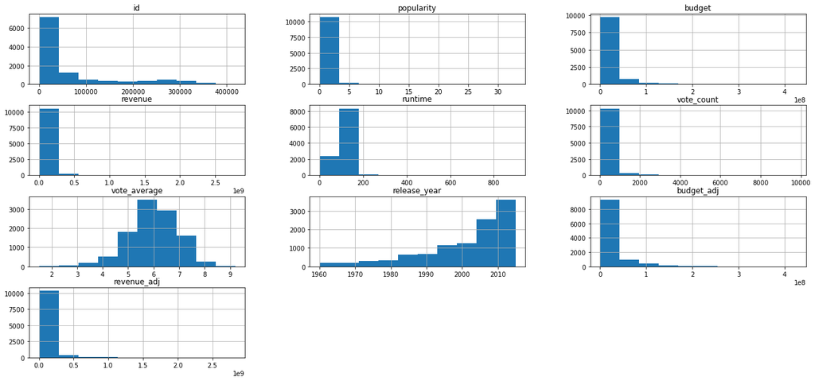

```python
df.hist(figsize=(22, 10))
fig = plt.gcf()
```

```python
df[df.duplicated()]
```

|  | id | imdb_id | popularity | budget | revenue | original_title | cast | homepage | director | tagline | keywords | overview | runtime | genres | production_companies | release_date | vote_count | vote_average | release_year | budget_adj | revenue_adj |
| --- | --- | --- | --- | --- | --- | --- | --- | --- | --- | --- | --- | --- | --- | --- | --- | --- | --- | --- | --- | --- | --- |
| 2090 | 42194 | tt0411951 | 0.59643 | 30000000 | 967000 | TEKKEN | Jon Foo\|Kelly Overton\|Cary-Hiroyuki Tagawa\|Ian Anthony Dale\|Luke Goss | NaN | Dwight H. Little | Survival is no game | martial arts\|dystopia\|based on video game\|martial arts tournament | In the year of 2039, after World Wars destroy much of the civilization as we know it, territories are no longer run by governments, but by corporations; the mightiest of which is the Mishima Zaibatsu.… | 92 | Crime\|Drama\|Action\|Thriller\|Science Fiction | Namco\|Light Song Films | 3/20/10 | 110 | 5.0 | 2010 | 30000000.0 | 967000.0 |

- id 42194 is duplicated and should be dropped

```python
all_columns = pd.Series(list(df))
all_columns[all_columns.duplicated()]
```

```
Series([], dtype: object)
```

```python
duplicateCol = []

for x in range(df.shape[1]):
    col = df.iloc[:, x]

    for y in range(x + 1, df.shape[1]):
        otherCol = df.iloc[:, y]

        if col.equals(otherCol):
            duplicateCol.append(df.columns.values[y])

print(duplicateCol)
```

```
[]
```

- No duplicate columns to be dropped.

### Data Cleaning:

After we have a look around the dataset, I will be doing some data cleaning to facilitate further analysis:

#### 1- Dropping Unnecessary Columns:

```python
df = df.drop(['imdb_id', 'budget', 'revenue', 'cast', 'homepage', 'tagline'], axis=1)
df.info()
```

```
<class 'pandas.core.frame.DataFrame'>
RangeIndex: 10866 entries, 0 to 10865
Data columns (total 15 columns):
 #   Column                Non-Null Count  Dtype
---  ------                --------------  -----
 0   id                    10866 non-null  int64
 1   popularity            10866 non-null  float64
 2   original_title        10866 non-null  object
 3   director              10822 non-null  object
 4   keywords              9373 non-null   object
 5   overview              10862 non-null  object
 6   runtime               10866 non-null  int64
 7   genres                10843 non-null  object
 8   production_companies  9836 non-null   object
 9   release_date          10866 non-null  object
 10  vote_count            10866 non-null  int64
 11  vote_average          10866 non-null  float64
 12  release_year          10866 non-null  int64
 13  budget_adj            10866 non-null  float64
 14  revenue_adj           10866 non-null  float64
dtypes: float64(4), int64(4), object(7)
memory usage: 1.2+ MB
```

#### 2- Correcting Data Types:

```python
df['id'] = df['id'].astype('object')
df['release_date'] = pd.to_datetime(df['release_date'])

df.info()
```

```
<class 'pandas.core.frame.DataFrame'>
RangeIndex: 10866 entries, 0 to 10865
Data columns (total 15 columns):
 #   Column                Non-Null Count  Dtype
---  ------                --------------  -----
 0   id                    10866 non-null  object
 1   popularity            10866 non-null  float64
 2   original_title        10866 non-null  object
 3   director              10822 non-null  object
 4   keywords              9373 non-null   object
 5   overview              10862 non-null  object
 6   runtime               10866 non-null  int64
 7   genres                10843 non-null  object
 8   production_companies  9836 non-null   object
 9   release_date          10866 non-null  datetime64[ns]
 10  vote_count            10866 non-null  int64
 11  vote_average          10866 non-null  float64
 12  release_year          10866 non-null  int64
 13  budget_adj            10866 non-null  float64
 14  revenue_adj           10866 non-null  float64
dtypes: datetime64[ns](1), float64(4), int64(3), object(7)
memory usage: 1.2+ MB
```

#### 3- Correcting Runtime limits:

Here, I will consider the movies with runtime between 45 and 4 hours assuming that longer runtimes will account to series and shows instead.

```python
df = df[(df['runtime']>=45) & (df['runtime']<=240)]
df.info()
```

```
<class 'pandas.core.frame.DataFrame'>
Int64Index: 10553 entries, 0 to 10865
Data columns (total 15 columns):
 #   Column                Non-Null Count  Dtype
---  ------                --------------  -----
 0   id                    10553 non-null  object
 1   popularity            10553 non-null  float64
 2   original_title        10553 non-null  object
 3   director              10522 non-null  object
 4   keywords              9165 non-null   object
 5   overview              10552 non-null  object
 6   runtime               10553 non-null  int64
 7   genres                10537 non-null  object
 8   production_companies  9614 non-null   object
 9   release_date          10553 non-null  datetime64[ns]
 10  vote_count            10553 non-null  int64
 11  vote_average          10553 non-null  float64
 12  release_year          10553 non-null  int64
 13  budget_adj            10553 non-null  float64
 14  revenue_adj           10553 non-null  float64
dtypes: datetime64[ns](1), float64(4), int64(3), object(7)
memory usage: 1.3+ MB
```

```python
df.describe()
```

|  | popularity | runtime | vote_count | vote_average | release_year | budget_adj | revenue_adj |
| --- | --- | --- | --- | --- | --- | --- | --- |
| count | 10553.000000 | 10553.000000 | 10553.000000 | 10553.000000 | 10553.000000 | 1.055300e+04 | 1.055300e+04 |
| mean | 0.655562 | 103.211504 | 222.407183 | 5.954373 | 2001.199469 | 1.800820e+07 | 5.281585e+07 |
| std | 1.009018 | 20.014802 | 583.226558 | 0.929394 | 12.836735 | 3.460336e+07 | 1.464462e+08 |
| min | 0.000188 | 45.000000 | 10.000000 | 1.500000 | 1960.000000 | 0.000000e+00 | 0.000000e+00 |
| 25% | 0.210972 | 90.000000 | 17.000000 | 5.400000 | 1994.000000 | 0.000000e+00 | 0.000000e+00 |
| 50% | 0.388026 | 99.000000 | 39.000000 | 6.000000 | 2005.000000 | 0.000000e+00 | 0.000000e+00 |
| 75% | 0.724013 | 112.000000 | 151.000000 | 6.600000 | 2011.000000 | 2.173537e+07 | 3.602000e+07 |
| max | 32.985763 | 240.000000 | 9767.000000 | 8.900000 | 2015.000000 | 4.250000e+08 | 2.827124e+09 |

#### 4- Dropping Duplicates:

```python
df = df.drop_duplicates()
df.info()
```

```
<class 'pandas.core.frame.DataFrame'>
Int64Index: 10552 entries, 0 to 10865
Data columns (total 15 columns):
 #   Column                Non-Null Count  Dtype
---  ------                --------------  -----
 0   id                    10552 non-null  object
 1   popularity            10552 non-null  float64
 2   original_title        10552 non-null  object
 3   director              10521 non-null  object
 4   keywords              9164 non-null   object
 5   overview              10551 non-null  object
 6   runtime               10552 non-null  int64
 7   genres                10536 non-null  object
 8   production_companies  9613 non-null   object
 9   release_date          10552 non-null  datetime64[ns]
 10  vote_count            10552 non-null  int64
 11  vote_average          10552 non-null  float64
 12  release_year          10552 non-null  int64
 13  budget_adj            10552 non-null  float64
 14  revenue_adj           10552 non-null  float64
dtypes: datetime64[ns](1), float64(4), int64(3), object(7)
memory usage: 1.3+ MB
```

#### 5. Dropping null observations after assignment of null genres as unclassified:

Here, I decided to replace the null genres with unclassified category and to drop the null observations accounting for director and production companies.

```python
df['genres'] = df['genres'].fillna('Unclassified')
df[df['genres']=='Unclassified']
df.info()
```

```
<class 'pandas.core.frame.DataFrame'>
Int64Index: 10552 entries, 0 to 10865
Data columns (total 15 columns):
 #   Column                Non-Null Count  Dtype
---  ------                --------------  -----
 0   id                    10552 non-null  object
 1   popularity            10552 non-null  float64
 2   original_title        10552 non-null  object
 3   director              10521 non-null  object
 4   keywords              9164 non-null   object
 5   overview              10551 non-null  object
 6   runtime               10552 non-null  int64
 7   genres                10552 non-null  object
 8   production_companies  9613 non-null   object
 9   release_date          10552 non-null  datetime64[ns]
 10  vote_count            10552 non-null  int64
 11  vote_average          10552 non-null  float64
 12  release_year          10552 non-null  int64
 13  budget_adj            10552 non-null  float64
 14  revenue_adj           10552 non-null  float64
dtypes: datetime64[ns](1), float64(4), int64(3), object(7)
memory usage: 1.3+ MB
```

```python
cols_1 = ['production_companies', 'director']
df.dropna(subset=cols_1, how='any', inplace=True)
df.info()
```

```
<class 'pandas.core.frame.DataFrame'>
Int64Index: 9599 entries, 0 to 10865
Data columns (total 15 columns):
 #   Column                Non-Null Count  Dtype
---  ------                --------------  -----
 0   id                    9599 non-null   object
 1   popularity            9599 non-null   float64
 2   original_title        9599 non-null   object
 3   director              9599 non-null   object
 4   keywords              8534 non-null   object
 5   overview              9599 non-null   object
 6   runtime               9599 non-null   int64
 7   genres                9599 non-null   object
 8   production_companies  9599 non-null   object
 9   release_date          9599 non-null   datetime64[ns]
 10  vote_count            9599 non-null   int64
 11  vote_average          9599 non-null   float64
 12  release_year          9599 non-null   int64
 13  budget_adj            9599 non-null   float64
 14  revenue_adj           9599 non-null   float64
dtypes: datetime64[ns](1), float64(4), int64(3), object(7)
memory usage: 1.2+ MB
```

#### 6. Replacing zero values with null values in the budget and revenue column:

Now, I need to replace all the ero budgets and revenues with Nan values to enable calculating the profits.

```python
df['budget_adj'] = df['budget_adj'].replace(0,np.nan)
df['revenue_adj'] = df['revenue_adj'].replace(0,np.nan)
df['profit'] = df['revenue_adj'] - df['budget_adj']
df.info()
```

```
<class 'pandas.core.frame.DataFrame'>
Int64Index: 9599 entries, 0 to 10865
Data columns (total 16 columns):
 #   Column                Non-Null Count  Dtype
---  ------                --------------  -----
 0   id                    9599 non-null   object
 1   popularity            9599 non-null   float64
 2   original_title        9599 non-null   object
 3   director              9599 non-null   object
 4   keywords              8534 non-null   object
 5   overview              9599 non-null   object
 6   runtime               9599 non-null   int64
 7   genres                9599 non-null   object
 8   production_companies  9599 non-null   object
 9   release_date          9599 non-null   datetime64[ns]
 10  vote_count            9599 non-null   int64
 11  vote_average          9599 non-null   float64
 12  release_year          9599 non-null   int64
 13  budget_adj            5002 non-null   float64
 14  revenue_adj           4744 non-null   float64
 15  profit                3803 non-null   float64
dtypes: datetime64[ns](1), float64(5), int64(3), object(7)
memory usage: 1.2+ MB
```

## Exploratory Data Analysis

### Research Question: What are the factors and trends detrmining the popularity of movies?

Question 1: What are the variales contributing to high popularity? Finding Correlation between our attributes

Question 2: How movies popularity changes over time?

Question 3: Exploring movies popularity and voting behavior across the years?

Question 4: Identyfing the most profitable and the least profitable movies with our dataset?

Question 5: How can the length of the movie affect its popularity?

Question 6: What are the most popular keywords the audience look for?

### Question 1: Finding Correlation between our attributes using heatmap:

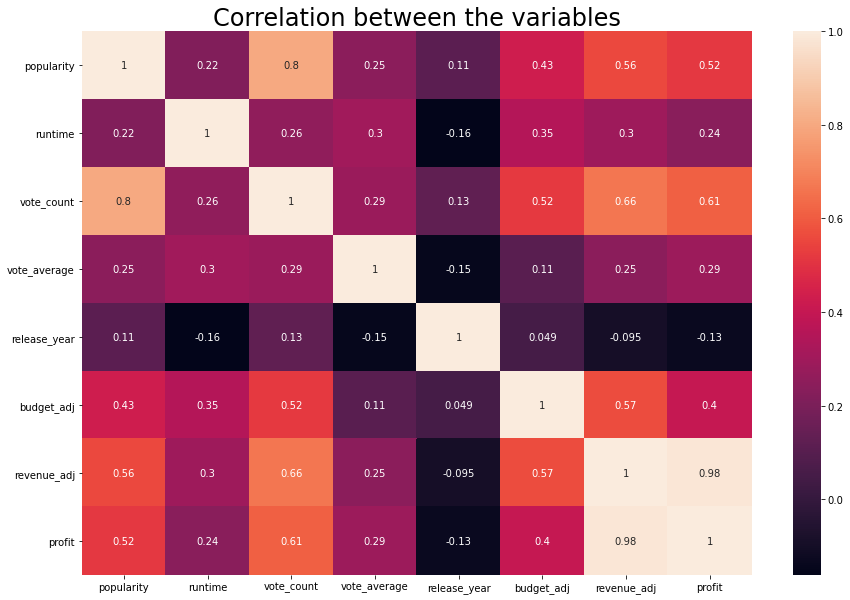

```python
plt.figure(figsize=(15, 10))
plt.title('Correlation between the variables' , fontsize = 24)
sns.heatmap(df.corr(),annot=True)
fig = plt.gcf()
```

From the heatmap we can find that many attributes are correlating positively with each other, for instance: Our dependent variable (popularity) has high correlation with profit and revenue, also revenue has high correlation with budget which suggests that higher budgets can be influencing the revenues directly and the popularity indirectly. Also, the corrleaction between profits and popularity suggests that popular movies may have been earning more profit. We can additionally emphasize that popularity has hish positive correlation with vote counts reflecting that highly popular movies are getting more votes. Finally runtime has a positive correlation with the budget, this may indicate that the longer the movie the higher cost it needs.

Now we need to explore further the trend of popularity through the years.

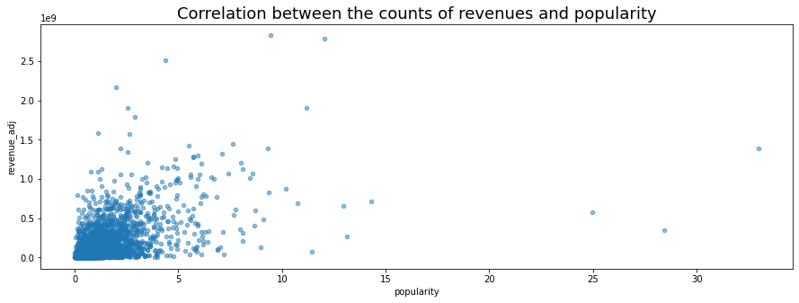

```python
df.plot.scatter(x='popularity', y='revenue_adj', colormap='rainbow', alpha=0.5, figsize=(15, 5))
plt.title('Correlation between the counts of revenues and popularity', fontsize = 18)
fig = plt.gcf()
```

### Question 2: Discovering movies popularity trends across the years:

```python
#Average yearly popularity of watching movies:
pop_avg = df['popularity'].groupby(df['release_year']).mean()
pop_med = df['popularity'].groupby(df['release_year']).median()
pop_avg.head(), pop_med.head()
```

```
(release_year
 1960    0.458932
 1961    0.430438
 1962    0.465245
 1963    0.480638
 1964    0.421091
 Name: popularity, dtype: float64,
 release_year
 1960    0.268273
 1961    0.273879
 1962    0.299075
 1963    0.232227
 1964    0.194941
 Name: popularity, dtype: float64)
```

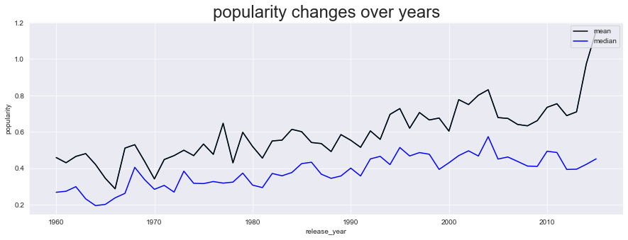

```python
sns.set_style('darkgrid')
plt.figure(figsize=(15, 5))

sns.lineplot(data=pop_avg)

ax1 = pop_avg.index
ay1 = pop_avg
ax2 = pop_med.index
ay2 = pop_med

#plot line chart for mean and median
plt.plot(ax1, ay1, color = 'black', label = 'mean')
plt.plot(ax2, ay2, color = 'blue', label = 'median')

plt.title('popularity changes over years', fontsize = 24)
plt.legend(loc='upper right')

fig = plt.gcf()
```

### Question 3: Exploring movies voting behavior and popularity across the years?

```python
votes = df[['popularity', 'vote_average']].groupby(df['release_year']).sum()
votes.head()
```

| release_year | popularity | vote_average |
| --- | --- | --- |
| 1960 | 14.685834 | 202.4 |
| 1961 | 12.913146 | 193.0 |
| 1962 | 13.957338 | 191.6 |
| 1963 | 15.380408 | 202.6 |
| 1964 | 17.264746 | 255.2 |

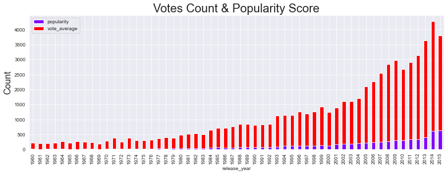

```python
votes.plot.bar(stacked=True, colormap='rainbow', figsize=(15, 5))
plt.title('Votes Count & Popularity Score', fontsize = 24)
plt.ylabel('Realse Year', fontsize = 18)
plt.ylabel('Count', fontsize = 18)
fig = plt.gcf()
```

### Question 4: Identyfing the most profitable and the least profitable movies with our dataset:

```python
top_mov = df[['original_title', 'vote_count', 'popularity', 'release_year']].groupby(df['profit']).max()
print(top_mov.head(), top_mov.tail())
```

```
                  original_title  vote_count  popularity  release_year
profit
-4.139124e+08  The Warrior's Way          74    0.250540          2010
-1.551102e+08    The Lone Ranger        1607    1.214510          2013
-1.375868e+08          The Alamo          60    0.948560          2004
-1.286813e+08   The 13th Warrior         275    1.189386          1999
-1.185350e+08       Brother Bear         753    1.653031          2003              original_title  vote_count  popularity  release_year
profit
1.878643e+09           Jaws        1415    2.563191          1975
2.128036e+09   The Exorcist        1113    2.010733          1973
2.234714e+09        Titanic        4654    4.355219          1997
2.586237e+09         Avatar        8458    9.432768          2009
2.750137e+09      Star Wars        4428   12.037933          1977
```

Here we can find that Star wars from 1977 is the most profitable movie in our dataset, it's popularity score is nearly 12, on the other side the least profitable movie is The Warrior's Way released in 2010 having a vote count of only 74.

This reflects that today's audience can have some interest in watching old movies.

### Question 5: How can the length of the movie affect its popularity?

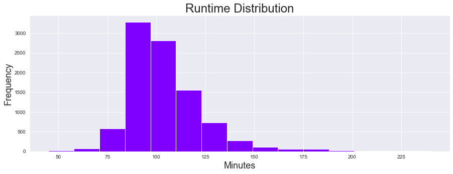

```python
df['runtime'].plot.hist(colormap='rainbow', figsize=(15, 5), bins=15)
plt.title('Runtime Distribution', fontsize = 24)
plt.xlabel('Minutes', fontsize = 18)
plt.ylabel('Frequency', fontsize = 18)
fig = plt.gcf()
```

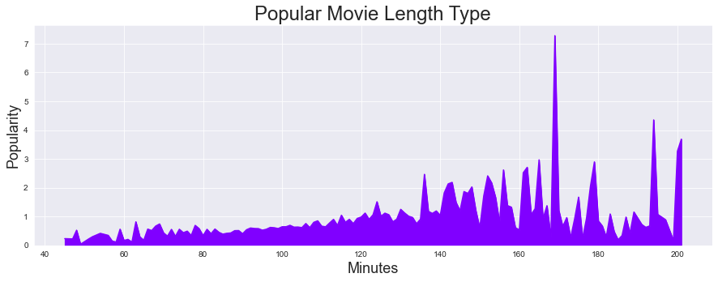

```python
runt_avg = df.groupby('runtime')['popularity'].mean().head(150)
runt_avg.plot.area(colormap='rainbow', figsize=(15, 5))
plt.title('Popular Movie Length Type', fontsize = 24)
plt.xlabel('Minutes', fontsize = 18)
plt.ylabel('Popularity', fontsize = 18)
fig = plt.gcf()
```

### Question 6: What are the most frequent search keywords?

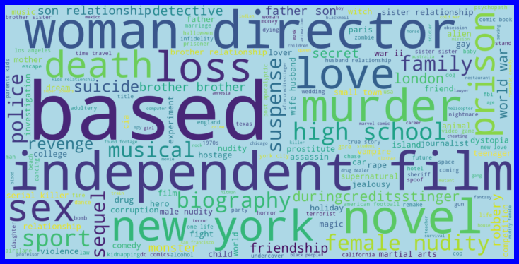

```python
keys = list(df['keywords'].str.cat(sep='|').split('|'))
wordcloud = WordCloud(width=2000, height=1000, repeat=False, background_color='lightblue').generate(" ".join(keys))
plt.figure(facecolor='blue', edgecolor='black', figsize=(15, 5))
plt.imshow(wordcloud, interpolation="bilinear")
plt.axis("off")
plt.tight_layout(pad=0)
plt.show()
```

We can find that popular keywords are reflecting the audience's directions like indepence, murder,woman, novel based, prison, loss, revenge.... These words supports that adventure genres will be more popular.

## Conclusions

### In conclusion to our efforts in exploring and analysing our dataset, we can highligh the following:

1- The technological revolution pushed the audience to easily access and evaluate movies over the years.

2- Most of the audience looks for suspense and thrill when searching for movies to watch.

3- Some movies from the past are still being watched nowadays, we can say that movie production can be having many treasures like star wars.

4- The length of the movie can a factor to consider when choosing a movie to watch, so it's better for producers to optimize the movie runtime.

## Limitations

1- The dataset was a bit historical, a more recent data would have helped better in the interpretation.

2- Many observations were missing, such as data relevent to budget and revenues, and keywords. I think these missing values may have changed some of the results.

3- The runtime data suggest including other midea species than movies, an additional variable to classify the media type would have facilitated the analysis process.